# HRS 2016 - Data Processing

Authors

Affiliations

Douglas Tommet

Brown University, Department of Psychiatry and Human Behavior

Richard N. Jones

Brown University, Department of Psychiatry and Human Behavior, Department of Neurology

HRS/HCAP Team

Published

August 7, 2026

Abstract

**Objective:** This pipeline prepares longitudinal Health and Retirement Study (HRS) data across four waves (2016, 2018, 2020, 2022) for analyses of cognitive aging and impairment. Starting from raw HRS and HCAP (Harmonized Cognitive Assessment Protocol) data files, the pipeline selects and standardizes variables, recodes demographic characteristics, and derives analytic covariates including restricted cubic spline age terms, race/ethnicity indicators, and educational attainment. Cognitive test items are recoded into binary correct/incorrect indicators and domain-level summary scores spanning orientation, naming, serial subtraction, word recall, animal fluency, and number series; continuous scores are then rescaled using a smoothed min-max normalization anchored to the 2016 wave to support cross-wave comparability. Functional status is characterized through binary ADL/IADL impairment indicators, a total impairment sum score, and informant-rated cognitive change via the JORM scale. External cognitive classification datasets (Langa-Weir and Hudomiet) are prepared and integrated alongside HCAP clinical diagnoses and domain impairment flags. Sampling weights are constructed for both the full HCAP sample and the consensus panel subsample using inverse-probability weighting. All processed datasets are merged into a single analytic spine and filtered into four analytic samples: the full tracker file, the HRS 2016 sample (age 65+, core interview), the HCAP 2016 subsample, and a multi-wave longitudinal sample covering any respondent with at least one core interview between 2016 and 2022.

# 1. Input data files

This script reads all raw source data files into R using `haven::read_dta()` and saves each as an `.rds` file for use in downstream processing steps. File paths are constructed using `fs::path()` relative to two root path variables — `hrs_data_path_source` (raw HRS/HCAP source data) and `hrs_data_path_derived` (derived HCAP products).

All files are in Stata `.dta` format. No recoding or variable transformation is performed at this stage.

## HRS Core Files

### Tracker

| Object | Source File | Description |
| --- | --- | --- |
| `tracker` | `trk2022v1/trk2022tr_r.dta` | HRS tracker file (2022 release); contains sampling design variables, wave membership indicators, weights, and demographics for all HRS respondents |

### Section Files (all four waves)

Section files are read for four HRS waves. Each wave contributes four sections:

| Section | Description |
| --- | --- |
| A (`H{yy}A_R.dta`) | Household and respondent identifiers, age |
| C (`H{yy}C_R.dta`) | Coverscreen / sample information |
| D (`H{yy}D_R.dta`) | Cognition and functional status |
| G (`H{yy}G_R.dta`) | IADL battery |

| Object | Source File |
| --- | --- |
| `h16a_r` | `HRS/2016/stata/H16A_R.dta` |
| `h16c_r` | `HRS/2016/stata/H16C_R.dta` |
| `h16d_r` | `HRS/2016/stata/H16D_R.dta` |
| `h16g_r` | `HRS/2016/stata/H16G_R.dta` |
| `h18a_r` | `HRS/2018/stata/H18A_R.dta` |
| `h18c_r` | `HRS/2018/stata/H18C_R.dta` |
| `h18d_r` | `HRS/2018/stata/H18D_R.dta` |
| `h18g_r` | `HRS/2018/stata/H18G_R.dta` |
| `h20a_r` | `HRS/2020/stata/H20A_R.dta` |
| `h20c_r` | `HRS/2020/stata/H20C_R.dta` |
| `h20d_r` | `HRS/2020/stata/H20D_R.dta` |
| `h20g_r` | `HRS/2020/stata/H20G_R.dta` |
| `h22a_r` | `HRS/2022/stata/H22A_R.dta` |
| `h22c_r` | `HRS/2022/stata/H22C_R.dta` |
| `h22d_r` | `HRS/2022/stata/H22D_R.dta` |
| `h22g_r` | `HRS/2022/stata/H22G_R.dta` |

## HCAP Files

| Object | Source File | Description |
| --- | --- | --- |
| `hc16hp_r` | `HCAP/HCAP2016/HC16sta/hc16hp_r.dta` | HCAP 2016 sampling weights |
| `normexcld` | `HCAP/2016/normexcld.dta` | Normative exclusion flags for the HCAP 2016 normative sample |
| `hrshcap` | `HCAP/2016/hrshcap.dta` | HCAP 2016 clinical diagnoses and cognitive domain impairment flags |
| `hcap_validation` | `stata/20240228-040.dta` | HCAP validation subsample (N=50); local project file |

## External Cognitive Classification Files

These are user-contributed datasets distributed through the HRS data portal.

| Object | Source File | Description |
| --- | --- | --- |
| `langa_weir` | `LangaWeir2020v2/cogfinalimp_9520wide.dta` | Langa-Weir dementia classification, waves 1995–2020, wide format |
| `hurd` | `DementiaPredictedProbabilities/pdem_withvarnames.dta` | Hurd dementia predicted probabilities (available through wave 2007 only) |
| `hudomiet` | `PredictedCognitionDementiaMeasures/Dementia_HRS_2000-2016_Basic_Release1_2m.dta` | Hudomiet probabilistic cognitive classification, waves 5–13 (2000–2016) |

## Output Data

All objects are saved as `.rds` files to the `R_objects/` directory:

| Object | Output File |
| --- | --- |
| `tracker` | `A0_005_tracker.rds` |
| `h16a_r`–`h16g_r` | `A0_005_h16a_r.rds`–`A0_005_h16g_r.rds` |
| `h18a_r`–`h18g_r` | `A0_005_h18a_r.rds`–`A0_005_h18g_r.rds` |
| `h20a_r`–`h20g_r` | `A0_005_h20a_r.rds`–`A0_005_h20g_r.rds` |
| `h22a_r`–`h22g_r` | `A0_005_h22a_r.rds`–`A0_005_h22g_r.rds` |
| `hc16hp_r` | `A0_005_hc16hp_r.rds` |
| `normexcld` | `A0_005_normexcld.rds` |
| `hrshcap` | `A0_005_hrshcap.rds` |
| `hcap_validation` | `A0_005_hcap_validation.rds` |
| `langa_weir` | `A0_005_langa_weir.rds` |
| `hurd` | `A0_005_hurd.rds` |
| `hudomiet` | `A0_005_hudomiet.rds` |

# 2. Data selection

## Input Data

| Object | Source File | Description |
| --- | --- | --- |
| `tracker` | `A0_005_tracker.rds` | HRS tracker file (sampling, demographics, weights) |
| `h16a_r` | `A0_005_h16a_r.rds` | HRS 2016 Section A (household/respondent info) |
| `h16d_r` | `A0_005_h16d_r.rds` | HRS 2016 Section D (cognition & function) |
| `h16g_r` | `A0_005_h16g_r.rds` | HRS 2016 Section G (IADL) |
| `normexcld` | `A0_005_normexcld.rds` | Normative exclusion flags |
| `hrshcap` | `A0_005_hrshcap.rds` | HCAP clinical diagnosis & domain scores |
| `hc16hp_r` | `A0_005_hc16hp_r.rds` | HCAP 2016 sampling weights |
| `hcap_validation` | `A0_005_hcap_validation.rds` | HRS/HCAP validation subsample (N=50) |
| `h18a_r` | `A0_005_h18a_r.rds` | HRS 2018 Section A (household/respondent info) |
| `h18d_r` | `A0_005_h18d_r.rds` | HRS 2018 Section D (cognition & function) |
| `h18g_r` | `A0_005_h18g_r.rds` | HRS 2018 Section G (IADL) |
| `h20a_r` | `A0_005_h20a_r.rds` | HRS 2020 Section A (household/respondent info) |
| `h20d_r` | `A0_005_h20d_r.rds` | HRS 2020 Section D (cognition & function) |
| `h20g_r` | `A0_005_h20g_r.rds` | HRS 2020 Section G (IADL) |
| `h22a_r` | `A0_005_h22a_r.rds` | HRS 2022 Section A (household/respondent info) |
| `h22d_r` | `A0_005_h22d_r.rds` | HRS 2022 Section D (cognition & function) |
| `h22g_r` | `A0_005_h22g_r.rds` | HRS 2022 Section G (IADL) |

## Processing Steps

### 1. Cognition (`hrs16_cog`)

Variables are selected from each wave’s Section D file covering the major cognitive domains assessed in HRS. The same variables are selected across all four waves (with wave-specific prefixes P/Q/R/S):

| Variable(s) | Domain |
| --- | --- |
| `xD174` | Immediate word recall (10-word list) |
| `xD184` | Delayed word recall |
| `xD151–xD154` | Orientation to time (month, day, year, day of week) |
| `xD124`, `xD129` | Backwards counting from 20 |
| `xD155–xD156` | Object naming (scissors, cactus) |
| `xD157–xD158` | President/vice-president naming |
| `xD142–xD146` | Serial 7s subtraction |
| `xD196`, `xD198` | Additional cognitive items |
| `xNSSCORE` | Nurse/proxy cognitive summary score (2016, 2020, 2022 only) |

For the 2016 wave (`hrs16_cog`), normative exclusion flags from `normexcld` are joined by `HHID`/`PN` to identify respondents who should be excluded from normative cognitive scoring. The 2018 wave data requires renaming of lowercase identifiers (`hhid`, `pn`, `qsubhh`) to match the uppercase convention used across waves.

### 2. HCAP Diagnosis & Domain Flags (`hrshcap`)

Variables are selected from the HCAP dataset covering:

- **Clinical diagnoses:** `vs1hcapdx` (primary), `vs1hcapdxeap` (expert adjudication panel)
- **Domain-level impairment flags** (memory, executive function, language/fluency, visuospatial, orientation) across standard and EAP scoring
- **Additional scales:** JORM informant report (`vs3jormsc_iflag`), Blessed scale (`vs3blessedsc_iflag`)

### 3. HCAP Sampling Weight (`hc16hp_r`)

`HCAP16WGTR` is retained alongside identifiers.

### 4. HCAP Validation Subsample (`hcap_validation`)

Retains `samplingP` (sampling probability) and `consensuspaneldx` (consensus panel diagnosis) for the N=50 validation subsample.

### 5. Functional Impairment — ADL (`hrs16_func`)

Variables are selected from `h16d_r` covering:

- `xD101`, `xD102` — Functional difficulty summary items (`PD101` added 2025-07-21)
- `xD502`, `xD505–xD553` — Full battery of ADL/functional limitation items
- `xD554`, `xD555`, `xD556` — Additional functional items (added 2026-05-12)

The same variable set is selected across all four waves.

### 6. Functional Impairment — IADL (`hrs16_iadl`)

Variables are selected from `h16g_r` covering:

- `xG013` — Screener item used to determine IADL skip patterns (`PG013` added 2025-07-26)
- `xG014`, `xG021`, `xG023`, `xG030`, `xG041`, `xG044`, `xG047`, `xG050`, `xG051`, `xG059` — Core IADL battery (dressing, bathing, eating, toileting, meal prep, grocery shopping, phone calls, medications, managing money)
- `xG040` — Map reading item (included in 2016, 2018, 2020 but **not available in 2022**)

### 7. Demographics & Sampling Weights (`tracker_demo`)

Core demographic and design variables are drawn from the tracker file and all four waves’ Section A files, then joined together.

**From `tracker`:**

| Variable | Description |
| --- | --- |
| `SECU`, `STRATUM` | Complex survey design variables |
| `HCAP16RESP` | HCAP 2016 response indicator |
| `PWGTR`–`SWGTR` | HRS person-level weights (all four waves) |
| `xIWTYPE` | Interview type (all four waves) |
| `xAGE` | Age at interview (all four waves) |
| `xINSAMP`, `xIWWAVE`, `xIWYEAR` | Sample/wave/year indicators (all four waves) |
| `xMARST` | Marital status (all four waves) |
| `xNURSHM` | Nursing home residence (all four waves) |
| `xPROXY` | Proxy interview flag (all four waves) |
| `GENDER`, `HISPANIC`, `RACE` | Sex/race/ethnicity |
| `SCHLYRS`, `DEGREE` | Education (years & degree) |
| `BIRTHYR` | Birth year |

**From Section A files (all four waves):**

`xA019` — Current age calculation

All four waves are joined sequentially to `tracker_demo` via `left_join` on `HHID`, `PN`, and the wave-specific sub-household identifier.

## Output Data

The following intermediate files are saved:

| Object | Output File | Key Content |
| --- | --- | --- |
| `hrs16_cog` | `A0_009_hrs16_cog.rds` | 2016 cognitive test items + normative exclusion flags |
| `hrs16_iadl` | `A0_009_hrs16_iadl.rds` | 2016 IADL items |
| `hrs16_func` | `A0_009_hrs16_func.rds` | 2016 ADL/functional limitation items |
| `hrs18_cog` | `A0_009_hrs18_cog.rds` | 2018 cognitive test items |
| `hrs18_iadl` | `A0_009_hrs18_iadl.rds` | 2018 IADL items |
| `hrs18_func` | `A0_009_hrs18_func.rds` | 2018 ADL/functional limitation items |
| `hrs20_cog` | `A0_009_hrs20_cog.rds` | 2020 cognitive test items |
| `hrs20_iadl` | `A0_009_hrs20_iadl.rds` | 2020 IADL items |
| `hrs20_func` | `A0_009_hrs20_func.rds` | 2020 ADL/functional limitation items |
| `hrs22_cog` | `A0_009_hrs22_cog.rds` | 2022 cognitive test items |
| `hrs22_iadl` | `A0_009_hrs22_iadl.rds` | 2022 IADL items (no SG040) |
| `hrs22_func` | `A0_009_hrs22_func.rds` | 2022 ADL/functional limitation items |
| `tracker_demo` | `A0_009_tracker_demo.rds` | Demographics, weights, survey design variables (all waves) |
| `hrshcap` | `A0_009_hrshcap.rds` | HCAP diagnoses and domain impairment flags |
| `hc16hp_r` | `A0_009_hc16hp_r.rds` | HCAP sampling weight |
| `hcap_validation` | `A0_009_hcap_validation.rds` | HCAP validation subsample (N=50) |

# 3. Sample identification

This section describes how the tracker demographic file and two HCAP auxiliary files (`hc16hp_r`, `hcap_validation`) are joined to `tracker_demo` and several derived variables are created. The created variables are a set of sample membership indicators, age eligibility flags, a unique respondent ID, and a recoded survey cluster variable for use in Mplus. Indicators are created for all four HRS waves (2016, 2018, 2020, 2022).

## Input Data

| Object | Source File | Description |
| --- | --- | --- |
| `tracker_demo` | `A0_009_tracker_demo.rds` | Demographics, weights, survey design variables |
| `hc16hp_r` | `A0_009_hc16hp_r.rds` | HCAP 2016 sampling weights |
| `hcap_validation` | `A0_009_hcap_validation.rds` | HCAP validation subsample (N=50) |

Both `hc16hp_r` and `hcap_validation` are joined to `tracker_demo` by `HHID` and `PN`.

The output is saved as `A0_010_tracker_demo.rds`.

### `inHRS_16` through `inHRS_22` — In HRS Core Interview

Binary indicators for whether the respondent completed a core HRS interview in each wave, based on the wave-specific interview type variable (`xIWTYPE`):

| Condition | Value |
| --- | --- |
| `xIWTYPE == 1` (core interview) | 1 |
| Any other value | 0 |

In HRS 2016 indicator

| In HRS 2016 | 2016 INTERVIEW TYPE | n |
| --- | --- | --- |
| 0 | 5 | 3874 |
| 0 | 11 | 1311 |
| 0 | 15 | 333 |
| 0 | 21 | 121 |
| 0 | 25 | 24 |
| 0 | 99 | 17120 |
| 1 | 1 | 20912 |

In HRS 2018 indicator

| In HRS 2018 | 2018 INTERVIEW TYPE | n |
| --- | --- | --- |
| 0 | 5 | 5890 |
| 0 | 11 | 981 |
| 0 | 15 | 493 |
| 0 | 21 | 114 |
| 0 | 25 | 45 |
| 0 | 99 | 19026 |
| 1 | 1 | 17146 |

In HRS 2020 indicator

| In HRS 2020 | 2020 INTERVIEW TYPE | n |
| --- | --- | --- |
| 0 | 5 | 5541 |
| 0 | 11 | 1266 |
| 0 | 15 | 622 |
| 0 | 21 | 116 |
| 0 | 25 | 28 |
| 0 | 99 | 20399 |
| 1 | 1 | 15723 |

In HRS 2022 indicator

| In HRS 2022 | 2022 INTERVIEW TYPE | n |
| --- | --- | --- |
| 0 | 5 | 6213 |
| 0 | 11 | 1201 |
| 0 | 15 | 686 |
| 0 | 21 | 109 |
| 0 | 25 | 20 |
| 0 | 99 | 22336 |
| 1 | 1 | 13130 |

### `nonzeroweight16` through `nonzeroweight22` — Positive Sampling Weight

Binary indicators for whether the respondent has a positive HRS person-level weight in each wave (`PWGTR`, `QWGTR`, `RWGTR`, `SWGTR`):

| Condition | Value |
| --- | --- |
| Weight is missing | 0 |
| Weight > 0 | 1 |
| Weight == 0 | 0 |

### `inHCAP` — In HCAP 2016

A binary indicator for HCAP participation, based on `HCAP16RESP`:

| `HCAP16RESP` | `inHCAP` | Notes |
| --- | --- | --- |
| 1 | 1 | Informant only |
| 2 | 1 | Respondent only |
| 3 | 1 | Both respondent and informant |
| 0 or other | 0 | No participation |

In HCAP 2016 indicator

| In HCAP 2016 | 2016 HCAP RESPONSE | n |
| --- | --- | --- |
| 0 | 0 | 929 |
| 0 | NA | 39270 |
| 1 | 1 | 149 |
| 1 | 2 | 313 |
| 1 | 3 | 3034 |

### `inSamplingFrame` — Weight and HCAP Membership Cross-Classification

A four-category labelled variable summarizing the cross-classification of 2016 weight status and HCAP participation:

| Value | Label | Condition |
| --- | --- | --- |
| 1 | In HCAP, has weight | `nonzeroweight16 == 1` AND `inHCAP == 1` |
| 2 | In HCAP, no weight | `nonzeroweight16 == 0` AND `inHCAP == 1` |
| 3 | Has weight, not in HCAP | `nonzeroweight16 == 1` AND `inHCAP == 0` |
| 4 | No weight, not in HCAP | `nonzeroweight16 == 0` AND `inHCAP == 0` |

In the sampling frame indicator

| Weight and HCAP indicator | Has positive 2016 sampling weight | In HCAP 2016 | n |
| --- | --- | --- | --- |
| 1 | 1 | 1 | 3417 |
| 2 | 0 | 1 | 79 |
| 3 | 1 | 0 | 16206 |
| 4 | 0 | 0 | 23993 |

### `age65up16` through `age65up22` — Age 65 or Older

Binary age eligibility indicators for each wave, derived from self-reported age. The Section A age variable (`xA019`) takes priority over the tracker age variable (`xAGE`):

| Condition | Value |
| --- | --- |
| `xA019 >= 65` | 1 |
| `xA019 < 65` | 0 |
| `xA019` missing AND `xAGE >= 65` | 1 |
| `xA019` missing AND `xAGE < 65` | 0 |
| Both `xA019` and `xAGE` missing | `NA` |

2016: Age 65+ indicator

| Age 65+ in 2016 | R CURRENT AGE CALCULATION | AGE AT 2016 INTERVIEW | n |
| --- | --- | --- | --- |
| 0 | 21 | 21 | 2 |
| 0 | 24 | 24 | 1 |
| 0 | 25 | 25 | 1 |
| 0 | 26 | 26 | 3 |
| 0 | 28 | 28 | 2 |
| 0 | 29 | 29 | 7 |
| 0 | 30 | 30 | 2 |
| 0 | 31 | 31 | 5 |
| 0 | 32 | 32 | 6 |
| 0 | 33 | 33 | 7 |
| 0 | 34 | 34 | 7 |
| 0 | 35 | 35 | 13 |
| 0 | 36 | 35 | 1 |
| 0 | 36 | 36 | 12 |
| 0 | 37 | 36 | 1 |
| 0 | 37 | 37 | 12 |
| 0 | 38 | 38 | 14 |
| 0 | 39 | 39 | 17 |
| 0 | 40 | 39 | 1 |
| 0 | 40 | 40 | 17 |
| 0 | 41 | 41 | 23 |
| 0 | 42 | 42 | 31 |
| 0 | 43 | 43 | 46 |
| 0 | 44 | 44 | 48 |
| 0 | 45 | 44 | 1 |
| 0 | 45 | 45 | 53 |
| 0 | 46 | 46 | 91 |
| 0 | 47 | 46 | 1 |
| 0 | 47 | 47 | 79 |
| 0 | 48 | 48 | 121 |

[output cut: 138 more lines]

2018: Age 65+ indicator

| Age 65+ in 2018 | R CURRENT AGE CALCULATION | AGE AT 2018 INTERVIEW | n |
| --- | --- | --- | --- |
| 0 | 22 | 22 | 1 |
| 0 | 26 | 26 | 1 |
| 0 | 27 | 27 | 2 |
| 0 | 28 | 28 | 1 |
| 0 | 29 | 29 | 1 |
| 0 | 30 | 30 | 2 |
| 0 | 31 | 31 | 4 |
| 0 | 32 | 32 | 3 |
| 0 | 33 | 33 | 4 |
| 0 | 34 | 34 | 6 |
| 0 | 35 | 35 | 4 |
| 0 | 36 | 36 | 6 |
| 0 | 37 | 37 | 9 |
| 0 | 38 | 38 | 12 |
| 0 | 39 | 39 | 18 |
| 0 | 40 | 40 | 10 |
| 0 | 41 | 41 | 21 |
| 0 | 42 | 41 | 1 |
| 0 | 42 | 42 | 8 |
| 0 | 43 | 42 | 1 |
| 0 | 43 | 43 | 26 |
| 0 | 44 | 44 | 29 |
| 0 | 45 | 44 | 1 |
| 0 | 45 | 45 | 38 |
| 0 | 46 | 45 | 1 |
| 0 | 46 | 46 | 39 |
| 0 | 46 | 47 | 1 |
| 0 | 47 | 46 | 2 |
| 0 | 47 | 47 | 51 |
| 0 | 48 | 48 | 72 |

[output cut: 141 more lines]

2020: Age 65+ indicator

| Age 65+ in 2020 | R CURRENT AGE CALCULATION | AGE AT 2020 INTERVIEW | n |
| --- | --- | --- | --- |
| 0 | 24 | 24 | 1 |
| 0 | 28 | 28 | 1 |
| 0 | 29 | 28 | 1 |
| 0 | 29 | 29 | 1 |
| 0 | 30 | 30 | 2 |
| 0 | 31 | 31 | 2 |
| 0 | 32 | 32 | 2 |
| 0 | 33 | 33 | 4 |
| 0 | 34 | 34 | 5 |
| 0 | 35 | 35 | 1 |
| 0 | 36 | 36 | 4 |
| 0 | 37 | 37 | 5 |
| 0 | 38 | 37 | 1 |
| 0 | 38 | 38 | 9 |
| 0 | 39 | 39 | 7 |
| 0 | 40 | 39 | 1 |
| 0 | 40 | 40 | 15 |
| 0 | 41 | 41 | 22 |
| 0 | 42 | 42 | 10 |
| 0 | 43 | 43 | 14 |
| 0 | 44 | 44 | 16 |
| 0 | 45 | 44 | 1 |
| 0 | 45 | 45 | 21 |
| 0 | 46 | 46 | 25 |
| 0 | 47 | 47 | 40 |
| 0 | 48 | 44 | 1 |
| 0 | 48 | 47 | 1 |
| 0 | 48 | 48 | 47 |
| 0 | 49 | 48 | 1 |
| 0 | 49 | 49 | 52 |

[output cut: 176 more lines]

2022: Age 65+ indicator

| Age 65+ in 2022 | R CURRENT AGE CALCULATION | AGE AT 2022 INTERVIEW | n |
| --- | --- | --- | --- |
| 0 | 27 | 27 | 1 |
| 0 | 29 | 29 | 1 |
| 0 | 30 | 30 | 2 |
| 0 | 31 | 31 | 1 |
| 0 | 32 | 32 | 1 |
| 0 | 33 | 33 | 1 |
| 0 | 34 | 34 | 1 |
| 0 | 35 | 35 | 3 |
| 0 | 36 | 36 | 5 |
| 0 | 37 | 37 | 1 |
| 0 | 38 | 38 | 1 |
| 0 | 39 | 39 | 7 |
| 0 | 40 | 40 | 6 |
| 0 | 41 | 41 | 7 |
| 0 | 42 | 42 | 13 |
| 0 | 43 | 42 | 2 |
| 0 | 43 | 43 | 14 |
| 0 | 44 | 44 | 14 |
| 0 | 45 | 45 | 10 |
| 0 | 46 | 45 | 1 |
| 0 | 46 | 46 | 17 |
| 0 | 47 | 47 | 16 |
| 0 | 48 | 48 | 27 |
| 0 | 49 | 48 | 1 |
| 0 | 49 | 49 | 33 |
| 0 | 50 | 46 | 1 |
| 0 | 50 | 49 | 1 |
| 0 | 50 | 50 | 36 |
| 0 | 51 | 51 | 50 |
| 0 | 51 | 52 | 1 |

[output cut: 180 more lines]

### `id` — Unique Respondent Identifier

A string identifier formed by concatenating `HHID` and `PN` with `str_c()`. Used as a row-level ID in Mplus analyses.

### `SECU_mplus` — Survey Cluster Variable for Mplus

A recoded cluster variable computed as:

$$\text{SECU\_mplus} = 10 \times \text{STRATUM} + \text{SECU}$$

This encoding creates a unique numeric identifier for each SECU-within-STRATUM combination in a format compatible with Mplus survey design specification.

### Output Data

| Object | Output File | Key Content |
| --- | --- | --- |
| `tracker_demo` | `A0_010_tracker_demo.rds` | tracker_demo with all derived sample indicators appended |

# 4. Data recoding

## Demographic variables

This section describes how the tracker demographic file produced in the prior step (`A0_010_tracker_demo.rds`) is used to perform five major operations:

1. **Imputes missing years of schooling** (`SCHLYRSimp`) using predictive mean matching (PMM) via `mice`
2. **Derives descriptive demographic variables** — sex, age categories, race/ethnicity, and educational attainment
3. **Computes restricted cubic spline age terms** for all four waves (2016, 2018, 2020, 2022)
4. **Constructs analysis covariates** (x1–x7 per wave) and all eligible two-way interactions
5. **Centers relevant covariates** using HCAP-weighted means estimated in the HCAP subsample, applied consistently across all four waves

### Input Data

| Object | Source File | Description |
| --- | --- | --- |
| `tracker_demo` | `A0_010_tracker_demo.rds` | Demographics, weights, and sample indicators |

The output is saved as `A0_011_tracker_demo.rds` and `A0_011_covariate_means.rds`.

### 1. Education Imputation (`SCHLYRSimp`)

Years of schooling (`SCHLYRS`) contains missing values coded as `99` and structural zeros in `BIRTHYR`. These are first recoded to `NA`. Five respondents also have manually verified education values (originally recoded in `015-Call-data-CORE-respondent.do`).

| HHID | PN | New SCHLYRS value |
| --- | --- | --- |
| 134189 | 020 | 14 |
| 502334 | 010 | 12 |
| 502607 | 010 | 10 |
| 905576 | 010 | 16 |
| 906962 | 010 | 12 |

Imputation is then carried out using `mice` with a single imputation (`m = 1`), predictive mean matching (`method = "pmm"`), and seed `2`. Predictors are: `DEGREE`, `GENDER`, `HISPANIC`, `RACE`, and `BIRTHYR`. The imputed values are stored as `SCHLYRSimp`.

### 2. Derived Demographic Variables

#### Age (`page`, `qage`, `rage`, `sage`)

Age variables for each wave are mapped directly from the Section A age variables: `page` = `PA019`, `qage` = `QA019`, `rage` = `RA019`, `sage` = `SA019`.

Age is also grouped into an ordered 6-category factor for each wave (`xage_cat`, `xage_cat_f`):

| Category | Age Range |
| --- | --- |
| 1 | 65–69 |
| 2 | 70–74 |
| 3 | 75–79 |
| 4 | 80–84 |
| 5 | 85–89 |
| 6 | 90 and over |

Ages below 65 are set to `NA`. Both a numeric (`xage_cat`) and ordered factor (`xage_cat_f`) version are created for each wave.

#### Sex (`female`)

| Female (from trk2022tr_r) | GENDER | n |
| --- | --- | --- |
| 0 | 1 | 19213 |
| 1 | 2 | 24277 |
| NA | NA | 205 |

#### Race and Ethnicity (`black`, `hisp`, `RaceAndEthnicity`)

Two binary indicators are derived:

- `black`: Black or African-American and **not** Hispanic
- `hisp`: Hispanic of any racial background (`HISPANIC` in 1, 2, 3)

| Black or African-American (not Hispanic) (from trk2022tr_r) | RACE/ETHNICITY | HISPANICITY TYPE | n |
| --- | --- | --- | --- |
| 0 | 0 | 0 | 1143 |
| 0 | 0 | 1 | 53 |
| 0 | 0 | 2 | 26 |
| 0 | 0 | 3 | 1 |
| 0 | 0 | 5 | 21 |
| 0 | 1 | 0 | 20 |
| 0 | 1 | 1 | 1855 |
| 0 | 1 | 2 | 1197 |
| 0 | 1 | 3 | 33 |
| 0 | 1 | 5 | 27668 |
| 0 | 2 | 1 | 16 |
| 0 | 2 | 2 | 133 |
| 0 | 2 | 3 | 5 |
| 0 | 7 | 0 | 20 |
| 0 | 7 | 1 | 1089 |
| 0 | 7 | 2 | 851 |
| 0 | 7 | 3 | 12 |
| 0 | 7 | 5 | 1577 |
| 1 | 2 | 0 | 18 |
| 1 | 2 | 5 | 7957 |

| Hispanic (from trk2022tr_r) | RACE/ETHNICITY | HISPANICITY TYPE | n |
| --- | --- | --- | --- |
| 0 | 0 | 0 | 1143 |
| 0 | 0 | 5 | 21 |
| 0 | 1 | 0 | 20 |
| 0 | 1 | 5 | 27668 |
| 0 | 2 | 0 | 18 |
| 0 | 2 | 5 | 7957 |
| 0 | 7 | 0 | 20 |
| 0 | 7 | 5 | 1577 |
| 1 | 0 | 1 | 53 |
| 1 | 0 | 2 | 26 |
| 1 | 0 | 3 | 1 |
| 1 | 1 | 1 | 1855 |
| 1 | 1 | 2 | 1197 |
| 1 | 1 | 3 | 33 |
| 1 | 2 | 1 | 16 |
| 1 | 2 | 2 | 133 |
| 1 | 2 | 3 | 5 |
| 1 | 7 | 1 | 1089 |
| 1 | 7 | 2 | 851 |
| 1 | 7 | 3 | 12 |

A four-category summary variable `RaceAndEthnicity` is also constructed with the following priority logic:

| Priority | Category | Code |
| --- | --- | --- |
| 1 | White | 1 |
| 2 | Black or African-American (Not Hispanic) | 2 |
| 3 (overrides 1–2) | Hispanic (any racial group) | 3 |
| 4 | All other racial groups | 4 |

| Race and ethnicity | RACE/ETHNICITY | HISPANICITY TYPE | n |
| --- | --- | --- | --- |
| 1 | 1 | 0 | 20 |
| 1 | 1 | 5 | 27668 |
| 2 | 2 | 0 | 18 |
| 2 | 2 | 5 | 7957 |
| 3 | 0 | 1 | 53 |
| 3 | 0 | 2 | 26 |
| 3 | 0 | 3 | 1 |
| 3 | 1 | 1 | 1855 |
| 3 | 1 | 2 | 1197 |
| 3 | 1 | 3 | 33 |
| 3 | 2 | 1 | 16 |
| 3 | 2 | 2 | 133 |
| 3 | 2 | 3 | 5 |
| 3 | 7 | 1 | 1089 |
| 3 | 7 | 2 | 851 |
| 3 | 7 | 3 | 12 |
| 4 | 0 | 0 | 1143 |
| 4 | 0 | 5 | 21 |
| 4 | 7 | 0 | 20 |
| 4 | 7 | 5 | 1577 |

#### Educational Attainment (`Educational_Attainment`)

A four-category labelled variable is derived from `SCHLYRSimp`:

| Category | Years of schooling |
| --- | --- |
| < High school | < 12 |
| High school | = 12 |
| Some college | 13–13 |
| Education beyond college | ≥ 14 |
| Unknown | Missing |

| Educational attainment | Number of years in school (imputed) | n |
| --- | --- | --- |
| 1 | 0 | 573 |
| 1 | 1 | 138 |
| 1 | 2 | 212 |
| 1 | 3 | 464 |
| 1 | 4 | 388 |
| 1 | 5 | 428 |
| 1 | 6 | 1022 |
| 1 | 7 | 699 |
| 1 | 8 | 2072 |
| 1 | 9 | 1489 |
| 1 | 10 | 2127 |
| 1 | 11 | 2143 |
| 2 | 12 | 13154 |
| 3 | 13 | 3210 |
| 4 | 14 | 4481 |
| 4 | 15 | 1605 |
| 4 | 16 | 4603 |
| 4 | 17 | 4887 |

### 3. Age Splines (`spage1`, `spage2`, `spage3`)

Restricted cubic splines (RCS) for age are computed using fixed knots at **70, 78, 86, and 94**, matching the parameterization used in prior HRS/HCAP analyses. The function `ageRCS()` implements the truncated power basis:

- `spage1`: Linear age term, **centered at 70** (deviation from age 70)
- `spage2`, `spage3`: Nonlinear spline components (zero at age 70 by construction)

| Wave | Age variable | Output variables |
| --- | --- | --- |
| 2016 | `page` | `spage1_16`, `spage2_16`, `spage3_16` |
| 2018 | `qage` | `spage1_18`, `spage2_18`, `spage3_18` |
| 2020 | `rage` | `spage1_20`, `spage2_20`, `spage3_20` |
| 2022 | `sage` | `spage1_22`, `spage2_22`, `spage3_22` |

> The knot placement reflects a hockey-stick-shaped age–cognition relationship in the HCAP normative sample: near-linear decline through most of the age range, with a reversal in the oldest-old due to selective survival. More parameters are therefore allocated to the upper age range.

### 4. Analysis Covariates (x1–x7, per wave)

Seven covariates are defined per wave for use in adjustment and classification models. The wave prefix follows the HRS convention (P=2016, Q=2018, R=2020, S=2022):

| Covariate | Source | Notes |
| --- | --- | --- |
| `x{w}1` | `spage1_{yr}` | Centered at age 70; only set for `inHRS_{yr}==1` |
| `x{w}2` | `spage2_{yr}` | Zero at age 70 by construction |
| `x{w}3` | `spage3_{yr}` | Zero at age 70 by construction |
| `x{w}4` | `female` | Centered at HCAP weighted mean |
| `x{w}5` | `black` | Centered at HCAP weighted mean |
| `x{w}6` | `hisp` | Centered at HCAP weighted mean |
| `x{w}7` | `SCHLYRSimp − 12` | Centered at 12 years of schooling |

Covariates are only populated for respondents present in the corresponding wave (`inHRS_{yr}==1`); all others are `NA`.

#### Two-Way Interactions

All pairwise interactions among x1–x7 are generated **except**:

- Interactions among x1, x2, and x3 (spline components with one another)
- The `x{w}5 × x{w}6` interaction (black × hisp), as no respondents in the sample are both Black and Hispanic

Interaction terms are named by concatenation (e.g., `xP1xP4`, `xQ2xQ5`). This pattern is applied identically to all four waves.

#### Centering of Demographic Covariates

`x{w}4` (female), `x{w}5` (black), `x{w}6` (hisp), and their interactions (`x{w}4x{w}5`, `x{w}4x{w}6`) are centered on **HCAP-weighted means** estimated from the `inHCAP == 1` subsample using 2016 survey design variables:

- Cluster: `SECU`
- Strata: `STRATUM`
- Weight: `HCAP16WGTR`

The five computed means are stored in the named list `covariate_means` and applied consistently to all four waves, so that centering is always relative to the 2016 HCAP reference distribution:

| Object | Stored mean |
| --- | --- |
| `xP4_mean` | Weighted mean of `female` |
| `xP5_mean` | Weighted mean of `black` |
| `xP6_mean` | Weighted mean of `hisp` |
| `xP4xP5_mean` | Weighted mean of `female × black` |
| `xP4xP6_mean` | Weighted mean of `female × hisp` |

> Although centering means are estimated within the HCAP subsample, the centered covariates are applied to the full `tracker_demo` dataset across all waves.

### Output Data

| Object | Output File | Key Content |
| --- | --- | --- |
| `tracker_demo` | `A0_011_tracker_demo.rds` | Full tracker_demo with imputed education, demographic recodes, age splines, covariates x1–x7, and interactions for all four waves |
| `covariate_means` | `A0_011_covariate_means.rds` | Named list of HCAP-weighted means used for centering, for reproducible application to future datasets |

## ADLs/IADLs

This section describes how the ADL/IADL data for all four HRS waves (2016, 2018, 2020, 2022) was recoded into binary impairment indicators (1 = impaired, 0 = not impaired). A sum score across all items is then computed per wave.

The recoding logic was updated from `PMM_041_Data_cleaning_functional_items.R`.

> **Note:** The 2022 wave (`hrs22_iadl`) does not include `G040` (Difficulty Using Maps), which was not collected in that wave. The sum score for 2022 therefore ranges from 0–9, while the sum score for 2016, 2018, and 2020 ranges from 0–10.

> **Note** As of 2026-05-12, the recoding logic was refactored into a function to support consistent application across waves.

### Input Data

| Object | Source File | Description |
| --- | --- | --- |
| `hrs16_iadl` | `A0_009_hrs16_iadl.rds` | HRS 2016 ADL/IADL raw items |
| `hrs18_iadl` | `A0_009_hrs18_iadl.rds` | HRS 2018 ADL/IADL raw items |
| `hrs20_iadl` | `A0_009_hrs20_iadl.rds` | HRS 2020 ADL/IADL raw items |
| `hrs22_iadl` | `A0_009_hrs22_iadl.rds` | HRS 2022 ADL/IADL raw items |

The output is saved as `A0_012_hrs{wave}_iadl.rds` for each wave.

### General Response Code Mapping

All items share the same base recoding scheme for their raw response codes:

| Raw Code | Meaning | Recoded Value |
| --- | --- | --- |
| 1 | Yes, has difficulty | 1 (Impaired) |
| 5 | No difficulty | 0 (Not impaired) |
| 6 | Can’t do / doesn’t do | 1 (Impaired) |
| 7 | Don’t know | `NA` |
| 8 | Refused / not applicable | `NA` |
| 9 | Not asked / volunteered | 1 (Impaired) |

### Additional Routing Rules

Several items have special routing logic tied to skip patterns in the HRS questionnaire. These apply identically across all four waves (substituting the appropriate wave prefix).

**`xG013` routing (items `rxG014`, `rxG021`, `rxG023`, `rxG030`):** Respondents with `xG013 == 0` (no difficulties reported on the screener) who are otherwise missing on a given item are recoded to **0** (not impaired), reflecting the intended skip logic.

**`xG014 == 5` routing (items `rxG021`, `rxG023`, `rxG030`):** If dressing (`xG014`) was not impaired and subsequent items are missing or coded 7/8, those items are recoded to **0**, again reflecting skip routing.

**`rxG050` — Difficulty Taking Medications:** This item has an additional follow-up question (`xG051`) that is used when `xG050 == 7` (don’t know):

| `xG050` | `xG051` | Recoded `rxG050` |
| --- | --- | --- |
| 7 | 1 | 1 (Impaired) |
| 7 | 5 | 0 (Not impaired) |
| 7 | 8 | `NA` |

## Derived Items

### Binary Impairment Indicators

The following indicators are derived for each wave. Wave prefixes follow the HRS convention (P = 2016, Q = 2018, R = 2020, S = 2022). The `xG040` item is only available for 2016, 2018, and 2020.

| Variable | Label | Type | Waves |
| --- | --- | --- | --- |
| `rxG014` | ADL: Difficulty Dressing | ADL | All |
| `rxG021` | ADL: Difficulty Bathing | ADL | All |
| `rxG023` | ADL: Difficulty Eating | ADL | All |
| `rxG030` | ADL: Difficulty Using Toilet | ADL | All |
| `rxG040` | IADL: Difficulty Using Maps | IADL | 2016, 2018, 2020 only |
| `rxG041` | IADL: Difficulty Meal Prep | IADL | All |
| `rxG044` | IADL: Difficulty Grocery Shopping | IADL | All |
| `rxG047` | IADL: Difficulty Making Phone Calls | IADL | All |
| `rxG050` | IADL: Difficulty Taking Medications | IADL | All |
| `rxG059` | IADL: Difficulty Managing Money | IADL | All |

All indicators are labelled: `1 = "Impaired"`, `0 = "Not impaired"`.

Table 1: ADL: Difficulty Dressing recoding

| ADL: Difficulty Dressing | DIFFICULTY- DRESSING | n |
| --- | --- | --- |
| 0 | 5 | 10875 |
| 0 | NA | 7609 |
| 1 | 1 | 2352 |
| 1 | 6 | 52 |
| 1 | 9 | 2 |
| NA | 7 | 12 |
| NA | 8 | 10 |

Table 2: ADL: Difficulty Bathing recoding

| ADL: Difficulty Bathing | DIFFICULTY BATHING | n |
| --- | --- | --- |
| 0 | 5 | 8552 |
| 0 | NA | 10618 |
| 1 | 1 | 1690 |
| 1 | 6 | 39 |
| 1 | 9 | 1 |
| NA | 7 | 6 |
| NA | 8 | 6 |

Table 3: ADL: Difficulty Eating recoding

| ADL: Difficulty Eating | DIFFICULTY EATING | n |
| --- | --- | --- |
| 0 | 5 | 9439 |
| 0 | NA | 10618 |
| 1 | 1 | 806 |
| 1 | 6 | 28 |
| 1 | 9 | 2 |
| NA | 7 | 15 |
| NA | 8 | 4 |

Table 4: ADL: Difficulty Using Toilet recoding

| ADL: Difficulty Using Toilet | DIFFICULTY USING TOILET | n |
| --- | --- | --- |
| 0 | 5 | 8892 |
| 0 | NA | 10618 |
| 1 | 1 | 1336 |
| 1 | 6 | 32 |
| 1 | 9 | 1 |
| NA | 7 | 23 |
| NA | 8 | 10 |

| IADL: Difficulty Using Maps | DIFFICULTY- USING MAPS | n |
| --- | --- | --- |
| 0 | 5 | 16811 |
| 1 | 1 | 2517 |
| 1 | 6 | 268 |
| 1 | 9 | 7 |
| NA | 7 | 1233 |
| NA | 8 | 39 |
| NA | NA | 37 |

Table 6: IADL: Difficulty Meal Prep recoding

| IADL: Difficulty Meal Prep | IADL MEAL PREPARATION DIFFICULTY | n |
| --- | --- | --- |
| 0 | 5 | 18880 |
| 1 | 1 | 1207 |
| 1 | 6 | 101 |
| 1 | 9 | 3 |
| NA | 7 | 679 |
| NA | 8 | 5 |
| NA | NA | 37 |

Table 7: IADL: Difficulty Grocery Shopping recoding

| IADL: Difficulty Grocery Shopping | IADL GROC SHOP DIFFICULTY | n |
| --- | --- | --- |
| 0 | 5 | 18324 |
| 1 | 1 | 1761 |
| 1 | 6 | 81 |
| 1 | 9 | 2 |
| NA | 7 | 701 |
| NA | 8 | 6 |
| NA | NA | 37 |

Table 8: IADL: Difficulty Making Phone Calls recoding

| IADL: Difficulty Making Phone Calls | IADL MAKING PHONE CALLS DIFFICULTY | n |
| --- | --- | --- |
| 0 | 5 | 19782 |
| 1 | 1 | 888 |
| 1 | 6 | 51 |
| 1 | 9 | 4 |
| NA | 7 | 146 |
| NA | 8 | 4 |
| NA | NA | 37 |

Table 9: IADL: Difficulty Taking Meds recoding

| IADL: Difficulty Taking Meds | IADL TAKING MEDICATION DIFFICULTY | IADL TAKING MEDS IF NEEDED DIFFICULTY | n |
| --- | --- | --- | --- |
| 0 | 5 | NA | 19671 |
| 0 | 7 | 5 | 202 |
| 1 | 1 | NA | 923 |
| 1 | 6 | NA | 24 |
| 1 | 7 | 1 | 41 |
| 1 | 9 | NA | 3 |
| NA | 7 | 8 | 6 |
| NA | 8 | NA | 5 |
| NA | NA | NA | 37 |

Table 10: IADL: Difficulty Managing Money Calls recoding

| IADL: Difficulty Managing Money | IADL MANAGING MONEY DIFFICULTY | n |
| --- | --- | --- |
| 0 | 5 | 18751 |
| 1 | 1 | 1339 |
| 1 | 6 | 53 |
| 1 | 9 | 7 |
| NA | 7 | 708 |
| NA | 8 | 17 |
| NA | NA | 37 |

Table 11: Descriptive statistics of recoded functional impairment items

| **Characteristic** | **N = 20,912**<sup>1</sup> |
| --- | --- |
| ADL: Difficulty Dressing |  |
| Impaired | 2,406 (12%) |
| Not impaired | 18,484 (88%) |
| Unknown | 22 |
| ADL: Difficulty Bathing |  |
| Impaired | 1,730 (8.3%) |
| Not impaired | 19,170 (92%) |
| Unknown | 12 |
| ADL: Difficulty Eating |  |
| Impaired | 836 (4.0%) |
| Not impaired | 20,057 (96%) |
| Unknown | 19 |
| ADL: Difficulty Using Toilet |  |
| Impaired | 1,369 (6.6%) |
| Not impaired | 19,510 (93%) |
| Unknown | 33 |
| IADL: Difficulty Using Maps |  |
| Impaired | 2,792 (14%) |
| Not impaired | 16,811 (86%) |
| Unknown | 1,309 |
| IADL: Difficulty Meal Prep |  |
| Impaired | 1,311 (6.5%) |
| Not impaired | 18,880 (94%) |
| Unknown | 721 |
| IADL: Difficulty Grocery Shopping |  |
| Impaired | 1,844 (9.1%) |
| Not impaired | 18,324 (91%) |
| Unknown | 744 |
| IADL: Difficulty Making Phone Calls |  |
| Impaired | 943 (4.6%) |
| Not impaired | 19,782 (95%) |
| Unknown | 187 |
| IADL: Difficulty Taking Meds |  |
| Impaired | 991 (4.7%) |
| Not impaired | 19,873 (95%) |
| Unknown | 48 |
| IADL: Difficulty Managing Money |  |
| Impaired | 1,399 (6.9%) |
| Not impaired | 18,751 (93%) |
| Unknown | 762 |
| Sum of ADL/IADL impairments |  |
| 0 | 14,812 (71%) |
| 1 | 2,952 (14%) |
| 2 | 1,034 (4.9%) |
| 3 | 649 (3.1%) |
| 4 | 448 (2.1%) |
| 5 | 302 (1.4%) |
| 6 | 247 (1.2%) |
| 7 | 150 (0.7%) |
| 8 | 130 (0.6%) |
| 9 | 100 (0.5%) |
| 10 | 88 (0.4%) |

<sup>1</sup> n (%)

### Sum Score (`r{x}iadl_imp`)

A row-wise sum of all binary indicators is computed per wave, yielding the total number of ADL/IADL domains with impairment. Missing values on individual items are ignored in the sum (`na.rm = TRUE`).

| Wave | Variable | Items included | Score range |
| --- | --- | --- | --- |
| 2016 | `rPiadl_imp` | `rPG014`, `rPG021`, `rPG023`, `rPG030`, `rPG040`, `rPG041`, `rPG044`, `rPG047`, `rPG050`, `rPG059` | 0–10 |
| 2018 | `rQiadl_imp` | `rQG014`, `rQG021`, `rQG023`, `rQG030`, `rQG040`, `rQG041`, `rQG044`, `rQG047`, `rQG050`, `rQG059` | 0–10 |
| 2020 | `rRiadl_imp` | `rRG014`, `rRG021`, `rRG023`, `rRG030`, `rRG040`, `rRG041`, `rRG044`, `rRG047`, `rRG050`, `rRG059` | 0–10 |
| 2022 | `rSiadl_imp` | `rSG014`, `rSG021`, `rSG023`, `rSG030`, `rSG041`, `rSG044`, `rSG047`, `rSG050`, `rSG059` | 0–9 |

### Output Data

| Object | Output File | Key Content |
| --- | --- | --- |
| `hrs16_iadl` | `A0_012_hrs16_iadl.rds` | 2016 recoded ADL/IADL indicators + sum score |
| `hrs18_iadl` | `A0_012_hrs18_iadl.rds` | 2018 recoded ADL/IADL indicators + sum score |
| `hrs20_iadl` | `A0_012_hrs20_iadl.rds` | 2020 recoded ADL/IADL indicators + sum score |
| `hrs22_iadl` | `A0_012_hrs22_iadl.rds` | 2022 recoded ADL/IADL indicators + sum score (no G040) |

## Informant & self-report of impairment

This section describes the functional data for all four HRS waves (2016, 2018, 2020, 2022) and derives four sets of informant/self-report measures of cognitive change:

1. **JORM items** (`r{x}jorm1`–`r{x}jorm16`) — 16-item informant-rated scale of cognitive change, constructed from wave-specific `xD506`–`xD553`
2. **JORM summary score** (`r{x}jorm`) — row-wise mean across the 16 JORM items
3. **Self-reported memory concern** (`r{x}self_concerns`) — binary composite from two self-report items (added 2025-07-21)
4. **Wandering/supervision items** (`r{x}D554`, `r{x}D555`, `r{x}D556`) — three binary indicators of wandering behavior and supervision needs (added 2026-05-12)

> **Note.** As of 2026-05-12, the recoding logic was refactored into a function to support consistent application across waves.

### Input Data

| Object | Source File | Description |
| --- | --- | --- |
| `hrs16_func` | `A0_009_hrs16_func.rds` | HRS 2016 functional/informant raw items |
| `hrs18_func` | `A0_009_hrs18_func.rds` | HRS 2018 functional/informant raw items |
| `hrs20_func` | `A0_009_hrs20_func.rds` | HRS 2020 functional/informant raw items |
| `hrs22_func` | `A0_009_hrs22_func.rds` | HRS 2022 functional/informant raw items |

The output is saved as `A0_013_hrs{wave}_func.rds` for each wave.

### Processing Steps

#### 1. JORM Item Construction (`r{x}jorm1`–`r{x}jorm16`)

Each JORM item is constructed from a **triplet** of raw HRS variables using a branching logic that maps the routing structure of the HRS questionnaire onto the standard 5-point JORM response scale. Wave prefixes follow the HRS convention (P = 2016, Q = 2018, R = 2020, S = 2022).

##### Source Variable Pairs

| JORM Item | Label | Raw Variables |
| --- | --- | --- |
| `r{x}jorm1` | Remembering things about family | xD506, xD507, xD508 |
| `r{x}jorm2` | Remembering things that happened recently | xD509, xD510, xD511 |
| `r{x}jorm3` | Recalling conversations a few days later | xD512, xD513, xD514 |
| `r{x}jorm4` | Remembering telephone numbers | xD515, xD516, xD517 |
| `r{x}jorm5` | Remembering day and month | xD518, xD519, xD520 |
| `r{x}jorm6` | Remembering where things are kept | xD521, xD522, xD523 |
| `r{x}jorm7` | Remembering where to find things | xD524, xD525, xD526 |
| `r{x}jorm8` | Knowing how to work familiar machines | xD527, xD528, xD529 |
| `r{x}jorm9` | Learning to use a new gadget | xD530, xD531, xD532 |
| `r{x}jorm10` | Learning new things in general | xD533, xD534, xD535 |
| `r{x}jorm11` | Following a story in a book or on TV | xD536, xD537, xD538 |
| `r{x}jorm12` | Making decisions on everyday matters | xD539, xD540, xD541 |
| `r{x}jorm13` | Handling money for shopping | xD542, xD543, xD544 |
| `r{x}jorm14` | Handling financial matters | xD545, xD546, xD547 |
| `r{x}jorm15` | Handling everyday arithmetic problems | xD548, xD549, xD550 |
| `r{x}jorm16` | Using intelligence to understand what’s going on | xD551, xD552, xD553 |

##### Branching Recoding Logic

Each item uses the same three-variable branching structure (illustrated below using generic variables A, B, C):

| Condition | Recoded Value | Label |
| --- | --- | --- |
| A == 1 AND B == 1 | 1 | Much improved |
| A == 1 AND B == 2 | 2 | A bit improved |
| A == 2 | 3 | Not much change |
| A == 3 AND C == 4 | 4 | A bit worse |
| A == 3 AND C == 5 | 5 | Much worse |

Where A is the primary routing variable, B captures improvement direction, and C captures worsening direction. Any combination not listed above yields `NA`.

#### 2. JORM Summary Score (`r{x}jorm`)

A row-wise mean of all 16 item scores is computed with `na.rm = TRUE`, yielding a continuous score ranging from 1 (much improved across all items) to 5 (much worse across all items). Items with missing values are excluded from the mean rather than set to zero.

#### 3. Self-Reported Memory Concern (`r{x}self_concerns`)

A binary composite is derived from two HRS items:

- **`xD101`** — *“How would you rate your memory at the present time?”*
- **`xD102`** — *“Compared to two years ago, would you say your memory is better, the same, or worse?”*

##### Recoding Rules (applied in priority order)

| Condition | `r{x}self_concerns` | Label |
| --- | --- | --- |
| `xD101` in {4, 5, 8, 9} — fair/poor or ambiguous rating | 1 | Worse or (Fair or Poor) |
| `xD102` in {3, 8, 9} — worse or ambiguous change | 1 | Worse or (Fair or Poor) |
| `xD101` in {1, 2, 3} — excellent/very good/good rating | 0 | (Same or Better) AND (Excellent, Very Good, Good) |
| All other cases | `NA` | — |

#### 4. Wandering and Supervision Items (`r{x}D554`, `r{x}D555`, `r{x}D556`)

*Added 2026-05-12.* Three binary items about wandering behavior and supervision needs are recoded from raw HRS variables:

| Variable | Label | Raw codes → Recoded value |
| --- | --- | --- |
| `r{x}D554` | Ever get lost in a familiar environment? | 1 → 1 (Yes); 5 → 0 (No); 8, 9 → `NA` |
| `r{x}D555` | Ever wander off and not return by herself/himself? | 1 → 1 (Yes); 5 → 0 (No); 8, 9 → `NA` |
| `r{x}D556` | Can’t be left alone for an hour or so? *(reversed)* | 1 → 0 (No); 5 → 1 (Yes); 8, 9 → `NA` |

> **Note:** `r{x}D556` is **reverse-coded** relative to the raw item so that a value of 1 consistently indicates the more impaired state (cannot be left alone).

All three items are labelled: `1 = "Yes"`, `0 = "No"`.

### Output Data

| Object | Output File | Key Content |
| --- | --- | --- |
| `hrs16_func` | `A0_013_hrs16_func.rds` | 2016 JORM items + summary score + self_concerns + wandering items |
| `hrs18_func` | `A0_013_hrs18_func.rds` | 2018 JORM items + summary score + self_concerns + wandering items |
| `hrs20_func` | `A0_013_hrs20_func.rds` | 2020 JORM items + summary score + self_concerns + wandering items |
| `hrs22_func` | `A0_013_hrs22_func.rds` | 2022 JORM items + summary score + self_concerns + wandering items |

## Cognitive Items

This section describes the raw HRS cognitive items for all four waves (2016, 2018, 2020, 2022) and performs two recoding operations.

1. **Recodes individual cognitive test items** into binary correct/incorrect indicators or cleaned continuous scores
2. **Constructs domain-level summary scores** by summing or combining item-level variables

> **Note:** The 2018 wave (`hrs18_cog`, wave prefix Q) does **not** include the Number Series item (`QNSSCORE` / `rQvdexf7`), as it was not administered in that wave.

> **Note:** As of 2026-05-12, the recoding logic was refactored into a function to support consistent application across waves:

### Input Data

| Object | Source File | Description |
| --- | --- | --- |
| `hrs16_cog` | `A0_009_hrs16_cog.rds` | HRS 2016 raw cognitive items |
| `hrs18_cog` | `A0_009_hrs18_cog.rds` | HRS 2018 raw cognitive items |
| `hrs20_cog` | `A0_009_hrs20_cog.rds` | HRS 2020 raw cognitive items |
| `hrs22_cog` | `A0_009_hrs22_cog.rds` | HRS 2022 raw cognitive items |

The output is saved as `A0_015_hrs{wave}_cog.rds` for each wave.

### 1. Item-Level Recoding

Wave prefixes follow the HRS convention: P = 2016, Q = 2018, R = 2020, S = 2022.

#### Orientation to Time (`r{x}D151`–`r{x}D154`)

Four date/time orientation items are each recoded to binary correct (1) / incorrect (0). Responses of don’t know (8) and refuse (9) are scored as **incorrect (0)**.

| Variable | Item | Source |
| --- | --- | --- |
| `r{x}D151` | Month | `xD151` |
| `r{x}D152` | Day | `xD152` |
| `r{x}D153` | Year | `xD153` |
| `r{x}D154` | Day of week | `xD154` |

| Raw Code | Recoded Value |
| --- | --- |
| 1 | 1 (Correct) |
| 5 | 0 (Incorrect) |
| 8 | 0 (Incorrect) |
| 9 | 0 (Incorrect) |

2016: Month

| Month | TODAYS DATE- MONTH | n |
| --- | --- | --- |
| 0 | 5 | 405 |
| 0 | 8 | 153 |
| 0 | 9 | 15 |
| 1 | 1 | 13127 |
| NA | NA | 7212 |

2016: Day

| Day | TODAYS DATE- DAY | n |
| --- | --- | --- |
| 0 | 5 | 2293 |
| 0 | 8 | 329 |
| 0 | 9 | 16 |
| 1 | 1 | 11062 |
| NA | NA | 7212 |

2016: Year

| Year | TODAYS DATE- YEAR | n |
| --- | --- | --- |
| 0 | 5 | 395 |
| 0 | 8 | 174 |
| 0 | 9 | 16 |
| 1 | 1 | 13115 |
| NA | NA | 7212 |

2016: Day of week

| Day of week | TODAYS DATE- DAY OF WEEK | n |
| --- | --- | --- |
| 0 | 5 | 466 |
| 0 | 8 | 110 |
| 0 | 9 | 14 |
| 1 | 1 | 13110 |
| NA | NA | 7212 |

2018: Month

| Month | TODAYS DATE- MONTH | n |
| --- | --- | --- |
| 0 | 5 | 282 |
| 0 | 8 | 151 |
| 0 | 9 | 12 |
| 1 | 1 | 7373 |
| NA | NA | 9328 |

2018: Day

| Day | TODAYS DATE- DAY | n |
| --- | --- | --- |
| 0 | 5 | 1461 |
| 0 | 8 | 267 |
| 0 | 9 | 12 |
| 1 | 1 | 6078 |
| NA | NA | 9328 |

2018: Year

| Year | TODAYS DATE- YEAR | n |
| --- | --- | --- |
| 0 | 5 | 302 |
| 0 | 8 | 153 |
| 0 | 9 | 12 |
| 1 | 1 | 7351 |
| NA | NA | 9328 |

2018: Day of week

| Day of week | TODAYS DATE- DAY OF WEEK | n |
| --- | --- | --- |
| 0 | 5 | 287 |
| 0 | 8 | 97 |
| 0 | 9 | 12 |
| 1 | 1 | 7422 |
| NA | NA | 9328 |

2020: Month

| Month | TODAYS DATE- MONTH | n |
| --- | --- | --- |
| 0 | 5 | 214 |
| 0 | 8 | 108 |
| 0 | 9 | 11 |
| 1 | 1 | 7028 |
| NA | NA | 8362 |

2020: Day

| Day | TODAYS DATE- DAY | n |
| --- | --- | --- |
| 0 | 5 | 1208 |
| 0 | 8 | 212 |
| 0 | 9 | 11 |
| 1 | 1 | 5930 |
| NA | NA | 8362 |

2020: Year

| Year | TODAYS DATE- YEAR | n |
| --- | --- | --- |
| 0 | 5 | 192 |
| 0 | 8 | 79 |
| 0 | 9 | 13 |
| 1 | 1 | 7077 |
| NA | NA | 8362 |

2020: Day of week

| Day of week | TODAYS DATE- DAY OF WEEK | n |
| --- | --- | --- |
| 0 | 5 | 238 |
| 0 | 8 | 52 |
| 0 | 9 | 11 |
| 1 | 1 | 7060 |
| NA | NA | 8362 |

2022: Month

| Month | TODAYS DATE- MONTH | n |
| --- | --- | --- |
| 0 | 5 | 246 |
| 0 | 8 | 126 |
| 0 | 9 | 6 |
| 1 | 1 | 9212 |
| NA | NA | 6266 |

2022: Day

| Day | TODAYS DATE- DAY | n |
| --- | --- | --- |
| 0 | 5 | 1566 |
| 0 | 8 | 263 |
| 0 | 9 | 6 |
| 1 | 1 | 7755 |
| NA | NA | 6266 |

2022: Year

| Year | TODAYS DATE- YEAR | n |
| --- | --- | --- |
| 0 | 5 | 389 |
| 0 | 8 | 114 |
| 0 | 9 | 6 |
| 1 | 1 | 9081 |
| NA | NA | 6266 |

2022: Day of week

| Day of week | TODAYS DATE- DAY OF WEEK | n |
| --- | --- | --- |
| 0 | 5 | 314 |
| 0 | 8 | 77 |
| 0 | 9 | 4 |
| 1 | 1 | 9195 |
| NA | NA | 6266 |

#### Object & Person Naming (`r{x}D155`–`r{x}D158`)

Four naming items recoded to binary correct (1) / incorrect (0). Don’t know and refuse are scored as **incorrect (0)**. The same recoding scheme as orientation items applies.

| Variable | Item | Source |
| --- | --- | --- |
| `r{x}D155` | Scissors (object naming) | `xD155` |
| `r{x}D156` | Cactus (object naming) | `xD156` |
| `r{x}D157` | President (person naming) | `xD157` |
| `r{x}D158` | Vice-president (person naming) | `xD158` |

2016: Object naming: Scissors

| Scissors | TOOL USED TO CUT PAPER | n |
| --- | --- | --- |
| 0 | 5 | 140 |
| 0 | 8 | 64 |
| 0 | 9 | 20 |
| 1 | 1 | 13476 |
| NA | NA | 7212 |

2016: Object naming: Cactus

| Cactus | NAME OF PRICKLY DESERT PLANT | n |
| --- | --- | --- |
| 0 | 5 | 396 |
| 0 | 8 | 690 |
| 0 | 9 | 22 |
| 1 | 1 | 12592 |
| NA | NA | 7212 |

2016: Person naming: President

| President | WHO IS THE PRESIDENT OF US | n |
| --- | --- | --- |
| 0 | 5 | 110 |
| 0 | 8 | 268 |
| 0 | 9 | 31 |
| 1 | 1 | 13290 |
| NA | NA | 7213 |

2016: Person naming: Vice-president

| Vice-president | WHO IS THE VICE-PRESIDENT OF US | n |
| --- | --- | --- |
| 0 | 5 | 1405 |
| 0 | 8 | 3637 |
| 0 | 9 | 39 |
| 1 | 1 | 8618 |
| NA | NA | 7213 |

2018: Object naming: Scissors

| Scissors | TOOL USED TO CUT PAPER | n |
| --- | --- | --- |
| 0 | 5 | 67 |
| 0 | 8 | 39 |
| 0 | 9 | 10 |
| 1 | 1 | 7702 |
| NA | NA | 9328 |

2018: Object naming: Cactus

| Cactus | NAME OF PRICKLY DESERT PLANT | n |
| --- | --- | --- |
| 0 | 5 | 232 |
| 0 | 8 | 421 |
| 0 | 9 | 15 |
| 1 | 1 | 7150 |
| NA | NA | 9328 |

2018: Person naming: President

| President | WHO IS THE PRESIDENT OF US | n |
| --- | --- | --- |
| 0 | 5 | 115 |
| 0 | 8 | 383 |
| 0 | 9 | 25 |
| 1 | 1 | 7295 |
| NA | NA | 9328 |

2018: Person naming: Vice-president

| Vice-president | WHO IS THE VICE-PRESIDENT OF US | n |
| --- | --- | --- |
| 0 | 5 | 707 |
| 0 | 8 | 2870 |
| 0 | 9 | 17 |
| 1 | 1 | 4224 |
| NA | NA | 9328 |

2020: Object naming: Scissors

| Scissors | TOOL USED TO CUT PAPER | n |
| --- | --- | --- |
| 0 | 5 | 76 |
| 0 | 8 | 29 |
| 0 | 9 | 11 |
| 1 | 1 | 7245 |
| NA | NA | 8362 |

2020: Object naming: Cactus

| Cactus | NAME OF PRICKLY DESERT PLANT | n |
| --- | --- | --- |
| 0 | 5 | 189 |
| 0 | 8 | 358 |
| 0 | 9 | 16 |
| 1 | 1 | 6798 |
| NA | NA | 8362 |

2020: Person naming: President

| President | WHO IS THE PRESIDENT OF US | n |
| --- | --- | --- |
| 0 | 5 | 115 |
| 0 | 8 | 196 |
| 0 | 9 | 17 |
| 1 | 1 | 7033 |
| NA | NA | 8362 |

2020: Person naming: Vice-president

| Vice-president | WHO IS THE VICE-PRESIDENT OF US | n |
| --- | --- | --- |
| 0 | 5 | 641 |
| 0 | 8 | 1704 |
| 0 | 9 | 17 |
| 1 | 1 | 4999 |
| NA | NA | 8362 |

2022: Object naming: Scissors

| Scissors | TOOL USED TO CUT PAPER | n |
| --- | --- | --- |
| 0 | 5 | 81 |
| 0 | 8 | 36 |
| 0 | 9 | 5 |
| 1 | 1 | 9467 |
| NA | NA | 6267 |

2022: Object naming: Cactus

| Cactus | NAME OF PRICKLY DESERT PLANT | n |
| --- | --- | --- |
| 0 | 5 | 277 |
| 0 | 8 | 465 |
| 0 | 9 | 10 |
| 1 | 1 | 8837 |
| NA | NA | 6267 |

2022: Person naming: President

| President | WHO IS THE PRESIDENT OF US | n |
| --- | --- | --- |
| 0 | 5 | 222 |
| 0 | 8 | 468 |
| 0 | 9 | 14 |
| 1 | 1 | 8885 |
| NA | NA | 6267 |

2022: Person naming: Vice-president

| Vice-president | WHO IS THE VICE-PRESIDENT OF US | n |
| --- | --- | --- |
| 0 | 5 | 851 |
| 0 | 8 | 2196 |
| 0 | 9 | 18 |
| 1 | 1 | 6524 |
| NA | NA | 6267 |

#### Serial 7s Subtraction (`r{x}D142`–`r{x}D146`)

Five sequential subtraction items. Each is scored correct (1) if the respondent’s answer equals the correct value for that step; don’t know (998), refuse (999), and any other non-missing, non-correct values are scored **incorrect (0)**.

Correctness for steps 2–5 is evaluated **relative to the prior response** (i.e., the respondent’s previous answer minus 7), not the expected absolute value — preserving credit for internally consistent sequences following an initial error.

| Variable | Item | Correct Answer Rule |
| --- | --- | --- |
| `r{x}D142` | Serial 7’s — 1 | `xD142 == 93` |
| `r{x}D143` | Serial 7’s — 2 | `xD143 == xD142 − 7` |
| `r{x}D144` | Serial 7’s — 3 | `xD144 == xD143 − 7` |
| `r{x}D145` | Serial 7’s — 4 | `xD145 == xD144 − 7` |
| `r{x}D146` | Serial 7’s — 5 | `xD146 == xD145 − 7` |

2016: Serial sevens

| Serial 7's - Number correct | Serial 7's - 1 | Serial 7's - 2 | Serial 7's - 3 | Serial 7's - 4 | Serial 7's - 5 | n |
| --- | --- | --- | --- | --- | --- | --- |
| 0 | 0 | 0 | 0 | 0 | 0 | 406 |
| 0 | 0 | 0 | 0 | 0 | NA | 43 |
| 0 | 0 | 0 | 0 | NA | NA | 116 |
| 0 | 0 | 0 | NA | NA | NA | 266 |
| 0 | 0 | NA | NA | NA | NA | 1014 |
| 1 | 0 | 0 | 0 | 0 | 1 | 58 |
| 1 | 0 | 0 | 0 | 1 | 0 | 69 |
| 1 | 0 | 0 | 1 | 0 | 0 | 68 |
| 1 | 0 | 0 | 1 | 0 | NA | 13 |
| 1 | 0 | 1 | 0 | 0 | 0 | 91 |
| 1 | 0 | 1 | 0 | 0 | NA | 14 |
| 1 | 0 | 1 | 0 | NA | NA | 31 |
| 1 | 1 | 0 | 0 | 0 | 0 | 698 |
| 1 | 1 | 0 | 0 | 0 | NA | 82 |
| 1 | 1 | 0 | 0 | NA | NA | 235 |
| 1 | 1 | 0 | NA | NA | NA | 754 |
| 2 | 0 | 0 | 0 | 1 | 1 | 36 |
| 2 | 0 | 0 | 1 | 0 | 1 | 48 |
| 2 | 0 | 0 | 1 | 1 | 0 | 49 |
| 2 | 0 | 1 | 0 | 0 | 1 | 24 |
| 2 | 0 | 1 | 0 | 1 | 0 | 42 |
| 2 | 0 | 1 | 1 | 0 | 0 | 46 |
| 2 | 0 | 1 | 1 | 0 | NA | 18 |
| 2 | 1 | 0 | 0 | 0 | 1 | 295 |
| 2 | 1 | 0 | 0 | 1 | 0 | 266 |
| 2 | 1 | 0 | 1 | 0 | 0 | 249 |
| 2 | 1 | 0 | 1 | 0 | NA | 52 |
| 2 | 1 | 1 | 0 | 0 | 0 | 327 |
| 2 | 1 | 1 | 0 | 0 | NA | 67 |
| 2 | 1 | 1 | 0 | NA | NA | 179 |
| 3 | 0 | 0 | 1 | 1 | 1 | 72 |
| 3 | 0 | 1 | 0 | 1 | 1 | 36 |
| 3 | 0 | 1 | 1 | 0 | 1 | 26 |
| 3 | 0 | 1 | 1 | 1 | 0 | 52 |
| 3 | 1 | 0 | 0 | 1 | 1 | 553 |
| 3 | 1 | 0 | 1 | 0 | 1 | 274 |
| 3 | 1 | 0 | 1 | 1 | 0 | 633 |
| 3 | 1 | 1 | 0 | 0 | 1 | 333 |
| 3 | 1 | 1 | 0 | 1 | 0 | 389 |
| 3 | 1 | 1 | 1 | 0 | 0 | 264 |
| 3 | 1 | 1 | 1 | 0 | NA | 44 |
| 4 | 0 | 1 | 1 | 1 | 1 | 107 |
| 4 | 1 | 0 | 1 | 1 | 1 | 1417 |
| 4 | 1 | 1 | 0 | 1 | 1 | 871 |
| 4 | 1 | 1 | 1 | 0 | 1 | 493 |
| 4 | 1 | 1 | 1 | 1 | 0 | 851 |
| 5 | 1 | 1 | 1 | 1 | 1 | 7899 |
| NA | NA | NA | NA | NA | NA | 942 |

2018: Serial sevens

| Serial 7's - Number correct | Serial 7's - 1 | Serial 7's - 2 | Serial 7's - 3 | Serial 7's - 4 | Serial 7's - 5 | n |
| --- | --- | --- | --- | --- | --- | --- |
| 0 | 0 | 0 | 0 | 0 | 0 | 346 |
| 0 | 0 | 0 | 0 | 0 | NA | 36 |
| 0 | 0 | 0 | 0 | NA | NA | 90 |
| 0 | 0 | 0 | NA | NA | NA | 181 |
| 0 | 0 | NA | NA | NA | NA | 844 |
| 1 | 0 | 0 | 0 | 0 | 1 | 51 |
| 1 | 0 | 0 | 0 | 1 | 0 | 75 |
| 1 | 0 | 0 | 1 | 0 | 0 | 55 |
| 1 | 0 | 0 | 1 | 0 | NA | 6 |
| 1 | 0 | 1 | 0 | 0 | 0 | 59 |
| 1 | 0 | 1 | 0 | 0 | NA | 10 |
| 1 | 0 | 1 | 0 | NA | NA | 29 |
| 1 | 1 | 0 | 0 | 0 | 0 | 546 |
| 1 | 1 | 0 | 0 | 0 | NA | 74 |
| 1 | 1 | 0 | 0 | NA | NA | 186 |
| 1 | 1 | 0 | NA | NA | NA | 620 |
| 2 | 0 | 0 | 0 | 1 | 1 | 34 |
| 2 | 0 | 0 | 1 | 0 | 1 | 32 |
| 2 | 0 | 0 | 1 | 1 | 0 | 41 |
| 2 | 0 | 1 | 0 | 0 | 1 | 20 |
| 2 | 0 | 1 | 0 | 1 | 0 | 33 |
| 2 | 0 | 1 | 1 | 0 | 0 | 33 |
| 2 | 0 | 1 | 1 | 0 | NA | 6 |
| 2 | 1 | 0 | 0 | 0 | 1 | 236 |
| 2 | 1 | 0 | 0 | 1 | 0 | 200 |
| 2 | 1 | 0 | 1 | 0 | 0 | 178 |
| 2 | 1 | 0 | 1 | 0 | NA | 40 |
| 2 | 1 | 1 | 0 | 0 | 0 | 243 |
| 2 | 1 | 1 | 0 | 0 | NA | 50 |
| 2 | 1 | 1 | 0 | NA | NA | 164 |
| 3 | 0 | 0 | 1 | 1 | 1 | 58 |
| 3 | 0 | 1 | 0 | 1 | 1 | 40 |
| 3 | 0 | 1 | 1 | 0 | 1 | 19 |
| 3 | 0 | 1 | 1 | 1 | 0 | 42 |
| 3 | 1 | 0 | 0 | 1 | 1 | 451 |
| 3 | 1 | 0 | 1 | 0 | 1 | 215 |
| 3 | 1 | 0 | 1 | 1 | 0 | 499 |
| 3 | 1 | 1 | 0 | 0 | 1 | 262 |
| 3 | 1 | 1 | 0 | 1 | 0 | 273 |
| 3 | 1 | 1 | 1 | 0 | 0 | 276 |
| 3 | 1 | 1 | 1 | 0 | NA | 53 |
| 4 | 0 | 1 | 1 | 1 | 1 | 87 |
| 4 | 1 | 0 | 1 | 1 | 1 | 1137 |
| 4 | 1 | 1 | 0 | 1 | 1 | 674 |
| 4 | 1 | 1 | 1 | 0 | 1 | 445 |
| 4 | 1 | 1 | 1 | 1 | 0 | 653 |
| 5 | 1 | 1 | 1 | 1 | 1 | 6781 |
| NA | NA | NA | NA | NA | NA | 663 |

2020: Serial sevens

| Serial 7's - Number correct | Serial 7's - 1 | Serial 7's - 2 | Serial 7's - 3 | Serial 7's - 4 | Serial 7's - 5 | n |
| --- | --- | --- | --- | --- | --- | --- |
| 0 | 0 | 0 | 0 | 0 | 0 | 260 |
| 0 | 0 | 0 | 0 | 0 | NA | 27 |
| 0 | 0 | 0 | 0 | NA | NA | 73 |
| 0 | 0 | 0 | NA | NA | NA | 188 |
| 0 | 0 | NA | NA | NA | NA | 645 |
| 1 | 0 | 0 | 0 | 0 | 1 | 38 |
| 1 | 0 | 0 | 0 | 1 | 0 | 60 |
| 1 | 0 | 0 | 1 | 0 | 0 | 42 |
| 1 | 0 | 0 | 1 | 0 | NA | 7 |
| 1 | 0 | 1 | 0 | 0 | 0 | 47 |
| 1 | 0 | 1 | 0 | 0 | NA | 16 |
| 1 | 0 | 1 | 0 | NA | NA | 17 |
| 1 | 1 | 0 | 0 | 0 | 0 | 459 |
| 1 | 1 | 0 | 0 | 0 | NA | 67 |
| 1 | 1 | 0 | 0 | NA | NA | 156 |
| 1 | 1 | 0 | NA | NA | NA | 573 |
| 2 | 0 | 0 | 0 | 1 | 1 | 42 |
| 2 | 0 | 0 | 1 | 0 | 1 | 19 |
| 2 | 0 | 0 | 1 | 1 | 0 | 21 |
| 2 | 0 | 1 | 0 | 0 | 1 | 18 |
| 2 | 0 | 1 | 0 | 1 | 0 | 31 |
| 2 | 0 | 1 | 1 | 0 | 0 | 28 |
| 2 | 0 | 1 | 1 | 0 | NA | 3 |
| 2 | 1 | 0 | 0 | 0 | 1 | 208 |
| 2 | 1 | 0 | 0 | 1 | 0 | 191 |
| 2 | 1 | 0 | 1 | 0 | 0 | 174 |
| 2 | 1 | 0 | 1 | 0 | NA | 33 |
| 2 | 1 | 1 | 0 | 0 | 0 | 188 |
| 2 | 1 | 1 | 0 | 0 | NA | 47 |
| 2 | 1 | 1 | 0 | NA | NA | 155 |
| 3 | 0 | 0 | 1 | 1 | 1 | 55 |
| 3 | 0 | 1 | 0 | 1 | 1 | 29 |
| 3 | 0 | 1 | 1 | 0 | 1 | 30 |
| 3 | 0 | 1 | 1 | 1 | 0 | 29 |
| 3 | 1 | 0 | 0 | 1 | 1 | 408 |
| 3 | 1 | 0 | 1 | 0 | 1 | 216 |
| 3 | 1 | 0 | 1 | 1 | 0 | 431 |
| 3 | 1 | 1 | 0 | 0 | 1 | 240 |
| 3 | 1 | 1 | 0 | 1 | 0 | 246 |
| 3 | 1 | 1 | 1 | 0 | 0 | 218 |
| 3 | 1 | 1 | 1 | 0 | NA | 35 |
| 4 | 0 | 1 | 1 | 1 | 1 | 72 |
| 4 | 1 | 0 | 1 | 1 | 1 | 970 |
| 4 | 1 | 1 | 0 | 1 | 1 | 632 |
| 4 | 1 | 1 | 1 | 0 | 1 | 391 |
| 4 | 1 | 1 | 1 | 1 | 0 | 663 |
| 5 | 1 | 1 | 1 | 1 | 1 | 6504 |
| NA | NA | NA | NA | NA | NA | 721 |

2022: Serial sevens

| Serial 7's - Number correct | Serial 7's - 1 | Serial 7's - 2 | Serial 7's - 3 | Serial 7's - 4 | Serial 7's - 5 | n |
| --- | --- | --- | --- | --- | --- | --- |
| 0 | 0 | 0 | 0 | 0 | 0 | 331 |
| 0 | 0 | 0 | 0 | 0 | NA | 38 |
| 0 | 0 | 0 | 0 | NA | NA | 69 |
| 0 | 0 | 0 | NA | NA | NA | 202 |
| 0 | 0 | NA | NA | NA | NA | 723 |
| 1 | 0 | 0 | 0 | 0 | 1 | 51 |
| 1 | 0 | 0 | 0 | 1 | 0 | 42 |
| 1 | 0 | 0 | 1 | 0 | 0 | 58 |
| 1 | 0 | 0 | 1 | 0 | NA | 10 |
| 1 | 0 | 1 | 0 | 0 | 0 | 52 |
| 1 | 0 | 1 | 0 | 0 | NA | 5 |
| 1 | 0 | 1 | 0 | NA | NA | 23 |
| 1 | 1 | 0 | 0 | 0 | 0 | 516 |
| 1 | 1 | 0 | 0 | 0 | NA | 65 |
| 1 | 1 | 0 | 0 | NA | NA | 190 |
| 1 | 1 | 0 | NA | NA | NA | 563 |
| 1 | 1 | NA | NA | NA | NA | 3 |
| 2 | 0 | 0 | 0 | 1 | 1 | 46 |
| 2 | 0 | 0 | 1 | 0 | 1 | 23 |
| 2 | 0 | 0 | 1 | 1 | 0 | 32 |
| 2 | 0 | 1 | 0 | 0 | 1 | 25 |
| 2 | 0 | 1 | 0 | 1 | 0 | 31 |
| 2 | 0 | 1 | 1 | 0 | 0 | 28 |
| 2 | 0 | 1 | 1 | 0 | NA | 8 |
| 2 | 1 | 0 | 0 | 0 | 1 | 222 |
| 2 | 1 | 0 | 0 | 1 | 0 | 192 |
| 2 | 1 | 0 | 1 | 0 | 0 | 198 |
| 2 | 1 | 0 | 1 | 0 | NA | 35 |
| 2 | 1 | 0 | 1 | NA | NA | 1 |
| 2 | 1 | 1 | 0 | 0 | 0 | 211 |
| 2 | 1 | 1 | 0 | 0 | NA | 49 |
| 2 | 1 | 1 | 0 | NA | NA | 161 |
| 2 | 1 | 1 | NA | NA | NA | 2 |
| 3 | 0 | 0 | 1 | 1 | 1 | 51 |
| 3 | 0 | 1 | 0 | 1 | 1 | 34 |
| 3 | 0 | 1 | 1 | 0 | 1 | 30 |
| 3 | 0 | 1 | 1 | 1 | 0 | 31 |
| 3 | 1 | 0 | 0 | 1 | 1 | 401 |
| 3 | 1 | 0 | 1 | 0 | 1 | 209 |
| 3 | 1 | 0 | 1 | 1 | 0 | 470 |
| 3 | 1 | 1 | 0 | 0 | 1 | 243 |
| 3 | 1 | 1 | 0 | 1 | 0 | 236 |
| 3 | 1 | 1 | 1 | 0 | 0 | 244 |
| 3 | 1 | 1 | 1 | 0 | NA | 58 |
| 3 | 1 | 1 | 1 | NA | NA | 3 |
| 4 | 0 | 1 | 1 | 1 | 1 | 90 |
| 4 | 1 | 0 | 1 | 1 | 1 | 1028 |
| 4 | 1 | 1 | 0 | 1 | 1 | 650 |
| 4 | 1 | 1 | 1 | 0 | 1 | 438 |
| 4 | 1 | 1 | 1 | 1 | 0 | 623 |
| 4 | 1 | 1 | 1 | 1 | NA | 5 |
| 5 | 1 | 1 | 1 | 1 | 1 | 6219 |
| NA | NA | NA | NA | NA | NA | 588 |

#### Animal Naming Errors `r{x}D198`)

`xD198` records the number of animal naming errors. Two special cases are handled before the score is used:

- `xD198 == 98` (coded as missing in HRS) → recoded to **1** (the median error value)
- `NA` → recoded to **1** (median imputation)

All other values are retained as-is.

#### Count Backwards from 20 (`r{x}vdcount`)

A binary indicator for whether the respondent correctly counted backwards from 20, allowing for two tries:

| Condition | `r{x}vdcount` |
| --- | --- |
| First try correct (`xD124 == 1`) OR second try correct (`xD129 == 1`) | 1 |
| First try incorrect (`xD124 == 5`), wants to restart (6), or refuses (9) | 0 |
| Second try incorrect (`xD129 == 5`) or refuses (9) | 0 |

2016: Count backwards from twenty

| Count backwards from 20 | IWER CHECK 20-1ST TRY | IWER CHECK 20- SECOND TRY | n |
| --- | --- | --- | --- |
| 0 | 5 | NA | 1324 |
| 0 | 6 | 5 | 11 |
| 0 | 6 | 9 | 2 |
| 0 | 9 | NA | 20 |
| 1 | 1 | NA | 18519 |
| 1 | 6 | 1 | 35 |
| NA | NA | NA | 1001 |

2018: Count backwards from twenty

| Count backwards from 20 | IWER CHECK 20-1ST TRY | IWER CHECK 20- SECOND TRY | n |
| --- | --- | --- | --- |
| 0 | 5 | NA | 1065 |
| 0 | 6 | 5 | 4 |
| 0 | 6 | 9 | 1 |
| 0 | 9 | NA | 19 |
| 1 | 1 | NA | 13916 |
| 1 | 6 | 1 | 19 |
| NA | NA | NA | 2122 |

2020: Count backwards from twenty

| Count backwards from 20 | IWER CHECK 20-1ST TRY | IWER CHECK 20- SECOND TRY | n |
| --- | --- | --- | --- |
| 0 | 5 | NA | 955 |
| 0 | 6 | 5 | 15 |
| 0 | 9 | NA | 18 |
| 1 | 1 | NA | 11901 |
| 1 | 6 | 1 | 50 |
| NA | NA | NA | 2784 |

2022: Count backwards from twenty

| Count backwards from 20 | IWER CHECK 20-1ST TRY | IWER CHECK 20- SECOND TRY | n |
| --- | --- | --- | --- |
| 0 | 5 | NA | 1025 |
| 0 | 6 | 5 | 21 |
| 0 | 6 | 9 | 1 |
| 0 | 9 | NA | 28 |
| 1 | 1 | 1 | 1 |
| 1 | 1 | NA | 12634 |
| 1 | 6 | 1 | 51 |
| NA | NA | NA | 2095 |

#### Word recall (`r{x}vdwdimm`, `r{x}vdwddel`)

Word recall items are carried forward with direct assignment:

| Variable | Label | Source |
| --- | --- | --- |
| `r{x}vdwdimm` | Word recall: Immediate | `xD174` |
| `r{x}vdwddel` | Word recall: Delayed | `xD184` |

#### Number series (`r{x}vdexf7`)

Available for 2016, 2020, and 2022 only — **not administered in 2018**. Codes 996, 997, and 999 are set to `NA`; all other non-missing values are retained.

| Variable | Label | Source | Notes |
| --- | --- | --- | --- |
| `r{x}vdexf7` | Number series | `xNSSCORE` | Codes 996, 997, 999 set to `NA` |

### 2. Domain-Level Summary Scores

All summaries are row-wise. If **all** component items are missing, the score is set to `NA` rather than 0. The same construction applies across all four waves.

| Score | Label | Components | Range |
| --- | --- | --- | --- |
| `r{x}vdori` | Orientation to Time | `r{x}D151`–`r{x}D154` | 0–4 |
| `r{x}vdlfl2` | Object naming | `r{x}D155`, `r{x}D156` | 0–2 |
| `r{x}vdlfl3` | Person naming | `r{x}D157`, `r{x}D158` | 0–2 |
| `r{x}vdsevens` | Serial 7’s — number correct | `r{x}D142`–`r{x}D146` | 0–5 |
| `r{x}vdlfl1` | Animal naming (correct − errors) | `xD196 − r{x}D198` | ≥ 0 (floored at 0) |

`r{x}vdlfl1` is floored at 0: if the number of errors exceeds the number of correct animals, the score is set to 0 rather than going negative.

### Output Data

| Object | Output File | Key Content |
| --- | --- | --- |
| `hrs16_cog` | `A0_015_hrs16_cog.rds` | 2016 recoded cognitive items and domain scores |
| `hrs16_cog_notes` | `A0_015_hrs16_cog_notes.rds` | Notes table documenting domain score construction |
| `hrs18_cog` | `A0_015_hrs18_cog.rds` | 2018 recoded cognitive items and domain scores (no `vdexf7`) |
| `hrs20_cog` | `A0_015_hrs20_cog.rds` | 2020 recoded cognitive items and domain scores |
| `hrs22_cog` | `A0_015_hrs22_cog.rds` | 2022 recoded cognitive items and domain scores |

## Cogntive Items Rescaling

This section describes the recoded cognitive data from the previous section and how a **smoothed min-max normalization** was applied to a subset of cognitive domain scores, producing scaled versions (suffix `z`) bounded approximately in [0, 1].

A key design decision is that **all four waves are rescaled using the 2016 wave as the reference distribution**. This means the min, max, and standard deviation used in the normalization formula are always drawn from the 2016 (`rPvd*`) variables, ensuring that the same raw test score maps to the same scaled value regardless of which wave it came from. This supports valid longitudinal comparisons across waves.

> **Note:** The 2018 wave does not include `vdexf7` (Number Series), so `rQvdexf7z` is not produced.

### Input Data

| Object | Source File | Description |
| --- | --- | --- |
| `hrs16_cog` | `A0_015_hrs16_cog.rds` | HRS 2016 recoded cognitive items and domain scores |
| `hrs18_cog` | `A0_015_hrs18_cog.rds` | HRS 2018 recoded cognitive items and domain scores |
| `hrs20_cog` | `A0_015_hrs20_cog.rds` | HRS 2020 recoded cognitive items and domain scores |
| `hrs22_cog` | `A0_015_hrs22_cog.rds` | HRS 2022 recoded cognitive items and domain scores |

The output is saved as `A0_016_hrs{wave}_cog.rds` for each wave.

### Normalization Function (`minmax`)

A custom smoothed min-max transformation is applied rather than a standard 0–1 rescaling. The formula is:

$$\tilde{x} = \frac{x - \min(x) + c_n}{\max(x) - \min(x) + c_d}$$

where $\text{x}$ is the **reference variable** (always the 2016 wave version of the same score), and the smoothing constants are derived from its standard deviation:

$$c_n = \frac{5}{8000} \cdot \text{SD}(x), \qquad c_d = \frac{10}{8000} \cdot \text{SD}(x)$$

The small additive constants $c_n$ (numerator) and $c_d$ (denominator) prevent the transformed values from collapsing exactly to 0 or 1 at the observed minimum and maximum, which is useful for downstream models (e.g., those involving log or logit links). Both constants scale with the standard deviation of the variable, keeping the adjustment proportionate across scores with different dispersions.

### Variables Transformed

Four cognitive scores receive the `minmax` transformation:

| Input Variable | Output Variable | Label | Waves |
| --- | --- | --- | --- |
| `r{x}vdlfl1` | `r{x}vdlfl1z` | Animal naming (correct − errors) | All |
| `r{x}vdwdimm` | `r{x}vdwdimmz` | Word recall — Immediate | All |
| `r{x}vdwddel` | `r{x}vdwddelz` | Word recall — Delayed | All |
| `r{x}vdexf7` | `r{x}vdexf7z` | Number series | 2016, 2020, 2022 only |

### Reference Distribution by Wave

| Wave | Object | Wave Letter | Reference Object | Reference Letter |
| --- | --- | --- | --- | --- |
| 2016 | `hrs16_cog` | P | `hrs16_cog` | P (self-reference) |
| 2018 | `hrs18_cog` | Q | `hrs16_cog` | P |
| 2020 | `hrs20_cog` | R | `hrs16_cog` | P |
| 2022 | `hrs22_cog` | S | `hrs16_cog` | P |

Using the 2016 wave as a common reference means a respondent with a raw animal naming score of, say, 15 in 2022 will receive the same scaled value as a respondent with a score of 15 in 2016, enabling direct cross-wave comparisons.

### Output Data

| Object | Output File | Key Content |
| --- | --- | --- |
| `hrs16_cog` | `A0_016_hrs16_cog.rds` | 2016 cognitive data with added `rPvdlfl1z`, `rPvdwdimmz`, `rPvdwddelz`, `rPvdexf7z` |
| `hrs18_cog` | `A0_016_hrs18_cog.rds` | 2018 cognitive data with added `rQvdlfl1z`, `rQvdwdimmz`, `rQvdwddelz` (no `vdexf7z`) |
| `hrs20_cog` | `A0_016_hrs20_cog.rds` | 2020 cognitive data with added `rRvdlfl1z`, `rRvdwdimmz`, `rRvdwddelz`, `rRvdexf7z` |
| `hrs22_cog` | `A0_016_hrs22_cog.rds` | 2022 cognitive data with added `rSvdlfl1z`, `rSvdwdimmz`, `rSvdwddelz`, `rSvdexf7z` |

## Diagnostic classification

This section describes how two external cognitive classification datasets — **Langa-Weir** and **Hudomiet** — were prepared for integration into the analytic pipeline. Both are trimmed to the relevant wave/variables, identifiers are standardized to `HHID`/`PN`, and a derived three-category Hudomiet classification variable is constructed.

A third classifier (Hurd dementia probabilities) was evaluated but excluded because it is only available through wave 2007, making it incompatible with the 2016 analytic wave.

*Input Data*

| Object | Source File | Description |
| --- | --- | --- |
| `langa_weir` | `A0_005_langa_weir.rds` | Langa-Weir cognitive status classification |
| `hudomiet` | `A0_005_hudomiet.rds` | Hudomiet probabilistic cognitive classification (waves 5–13) |
| `hurd` | `A0_005_hurd.rds` | Hurd dementia probabilities (excluded; only available through 2007) |

### 1. Langa-Weir (`langa_weir`)

Only the cognitive status variable for 2016 is retained:

| Variable | Description |
| --- | --- |
| `HHID` | Household identifier |
| `PN` | Person number |
| `cogfunction2016` | Langa-Weir cognitive function classification, 2016 wave |

### 2. Hudomiet (`hudomiet`)

#### Wave Filtering

The Hudomiet dataset spans waves 5 (year 2000) through 13 (year 2016). Only **wave 13** (2016) is retained.

#### Variable Selection

Five variables are kept from the filtered dataset:

| Variable | Description |
| --- | --- |
| `PrDem` | Posterior probability of dementia |
| `PrCIND` | Posterior probability of cognitive impairment, no dementia (CIND) |
| `PrNorm` | Posterior probability of normal cognition |
| `Cog` | Posterior mean of the latent cognitive factor |
| `CogSd` | Posterior standard deviation of the latent cognitive factor |

#### Identifier Parsing

The Hudomiet file uses a single concatenated identifier `hhidpn` rather than separate `HHID` and `PN` columns. This is parsed into components using the following steps:

1. Zero-pad `hhidpn` to 9 digits using `sprintf("%009.0f", ...)`
2. Reverse the string
3. Extract the first 3 characters → reversed `PN` → reverse back to get `PN`
4. Extract characters 4–9 → reversed `HHID` → reverse back to get `HHID`
5. Drop all intermediate parsing columns

#### Hudomiet Classification (`Hudomiet_classification`)

A three-category classification is derived by assigning each respondent to the cognitive status with the **highest posterior probability**:

| Value | Label | Rule |
| --- | --- | --- |
| 1 | Normal | `PrNorm ≥ PrCIND` AND `PrNorm ≥ PrDem` |
| 2 | CIND | `PrCIND ≥ PrDem` AND `PrCIND > PrNorm` |
| 3 | Dementia | `PrDem > PrCIND` AND `PrDem > PrNorm` |
| `NA` | — | No condition met (ties not resolved) |

The variable is labelled: *“Hudomiet classification by highest class proportion”*.

### Output Data

| Object | Output File | Key Content |
| --- | --- | --- |
| `langa_weir` | `A0_017_langa_weir.rds` | Langa-Weir 2016 cognitive classification with standardized identifiers |
| `hudomiet` | `A0_017_hudomiet.rds` | Hudomiet wave 13 probabilities, parsed identifiers, and derived classification |

## Consensus sample weights

This section describes the tracker demographics is used to construct two variables needed for analyses that use the **HCAP consensus panel diagnosis** (`consensuspaneldx`) as an outcome:

1. **`inConsensus`** — a binary subpopulation membership indicator
2. **`HCAP16WGTR_consensus`** — a sampling weight adjusted for the probability of selection into the consensus panel subsample and normalized to sum to 100

> **Note on proxy interviews:** The tracker variable `PPROXY` distinguishes core interviews obtained with a proxy (codes 1, 2) from non-proxy core interviews (code 5) and interviews not obtained (code 9). Informant-only HCAP cases arise from this structure and affect the `samplingP` variable — see missing weight handling below.

### Input Data

| Object | Source File | Description |
| --- | --- | --- |
| `tracker_demo` | `A0_011_tracker_demo.rds` | Demographics, weights, and sample indicators including `HCAP16WGTR`, `samplingP`, `inHCAP`, and `consensuspaneldx` |

The output is saved as `A0_021_tracker_demo.rds`.

### 1. Consensus Panel Sampling Weight (`HCAP16WGTR_consensus`)

The base HCAP sampling weight (`HCAP16WGTR`) is adjusted for the **inverse probability of selection** into the consensus panel subsample:

$$w_{\text{consensus}} = \text{HCAP16WGTR} \times \frac{1}{\text{samplingP}}$$

where `samplingP` is the probability that a given HCAP respondent was selected for consensus panel review. This inverse-probability weighting ensures that the consensus subsample is representative of the full HCAP-eligible population.

#### Normalization

The weight is then **normalized to sum to 100** among respondents with `inConsensus == 1`:

$$w_{\text{consensus, normalized}} = \frac{w_{\text{consensus}}}{\sum_{i \in \text{Consensus}} w_{\text{consensus},i}} \times 100$$

#### Missing Weight Handling

Respondents who are in HCAP (`inHCAP == 1`) but have a missing `HCAP16WGTR_consensus` — which occurs when `samplingP` is missing, as in informant-only cases — have their weight set to **0** rather than left as `NA`.

### 2. Consensus Subpopulation Indicator (`inConsensus`)

A three-valued indicator is derived to flag membership in the consensus panel subsample, defined only within the HCAP sample:

| Condition | `inConsensus` |
| --- | --- |
| `inHCAP == 0` (not in HCAP) | `NA` |
| `inHCAP == 1` AND `consensuspaneldx` is not missing | 1 |
| `inHCAP == 1` AND `consensuspaneldx` is missing | 0 |

Respondents outside HCAP receive `NA` rather than 0 to distinguish non-eligibility from non-selection.

> Note: `inConsensus` is constructed **after** `HCAP16WGTR_consensus` in the script, but is described first here because its definition clarifies which respondents the normalization denominator is summed over.

### Variable Labels

| Variable | Label |
| --- | --- |
| `inConsensus` | Indicator for HRS/HCAP consensuspaneldx subpopulation |
| `HCAP16WGTR_consensus` | Normalized sampling weight for consensuspaneldx |

### Output Data

| Object | Output File | Key Content |
| --- | --- | --- |
| `tracker_demo` | `A0_021_tracker_demo.rds` | tracker_demo with `inConsensus` and `HCAP16WGTR_consensus` appended |

# 5. Merging files together

This section describes how all the upstream analytic data objects are brought together into a single merged file, applies a structured variable selection, and constructs four analytic samples. A CONSORT-style flow diagram is generated to document sample attrition at each step for the 2016 HCAP sample.

*Input Data*

[output not shown]

## 1. Merging

| Dataset(s) | Join Keys |
| --- | --- |
| `langa_weir`, `hudomiet`, `hrshcap` | `HHID`, `PN` |
| `hrs16_cog`, `hrs16_func`, `hrs16_iadl` | `HHID`, `PN`, `PSUBHH` |
| `hrs18_cog`, `hrs18_func`, `hrs18_iadl` | `HHID`, `PN`, `QSUBHH` |
| `hrs20_cog`, `hrs20_func`, `hrs20_iadl` | `HHID`, `PN`, `RSUBHH` |
| `hrs22_cog`, `hrs22_func`, `hrs22_iadl` | `HHID`, `PN`, `SSUBHH` |

The wave-specific sub-household identifier (`xSUBHH`) is required as a join key for the wave-level data files to uniquely identify respondents within households across waves.

## 2. Variable Selection

After merging, columns are reordered and a priority variable list is applied using `select()`. Variables are organized into the following groups, with `everything()` appending any remaining columns not explicitly listed:

| Group | Key Variables |
| --- | --- |
| Identifiers | `id`, `HHID`, `PN` |
| Survey design & weights | `SECU`, `STRATUM`, `SECU_mplus`, `HCAP16WGTR`, `samplingP`, `inHCAP` |
| Wave membership | `inHRS_16`–`inHRS_22`, `nonzeroweight16`–`nonzeroweight22` |
| Wave-specific weights & tracking | `PWGTR`, `PINSAMP`, `PIWWAVE`, `PIWYEAR` (repeated for Q/R/S waves) |
| Age (continuous & categorical) | `page`, `page_cat`, `page_cat_f` (repeated for Q/R/S waves) |
| Demographics | `female`, `black`, `hisp`, `SCHLYRS`, `HISPANIC`, `RACE` |
| Cognitive scores — 2016 | `rPvdori`, `rPvdlfl1z`, `rPvdlfl2`, `rPvdlfl3`, `rPvdwdimmz`, `rPvdwddelz`, `rPvdexf7z`, `rPvdsevens`, `rPvdcount` |
| Cognitive scores — 2018 | Same as 2016 with Q prefix; **no `rQvdexf7z`** |
| Cognitive scores — 2020/2022 | Same as 2016 with R/S prefix |
| ADL/IADL & functional | `rPiadl_imp`, `rPjorm`, `rPself_concerns`, `rPD554`, `rPD555`, `rPD556` (repeated for Q/R/S waves) |
| Diagnoses & classification | `normexcld`, `vs1hcapdx`, `vs1hcapdxeap`, `inConsensus`, `HCAP16WGTR_consensus`, `consensuspaneldx` |
| Langa-Weir | `cogfunction2016` |
| Hudomiet | `PrDem`, `PrCIND`, `PrNorm`, `Cog`, `CogSd`, `Hudomiet_classification` |
| Wave-specific status | `PMARST`, `PNURSHM`, `PPROXY` (repeated for Q/R/S waves) |
| All remaining | `everything()` |

## 3. Sample Exclusion & CONSORT Diagram

Four sequential exclusion flags are constructed to define the 2016-based analytic samples:

| Flag | Exclusion Criterion |
| --- | --- |
| `not_in_hrs16` | `PIWTYPE != 1` — did not complete a core HRS 2016 interview |
| `not_in_sampling_frame` | `nonzeroweight16 == 0` AND `inHCAP == 0` — zero sampling weight and not in HCAP |
| `age_young_or_not_in_hcap` | `age65up16 == 0` AND `inHCAP == 0` — under age 65 and not in HCAP |
| `not_in_hcap` | `inHCAP == 0` — not in the HCAP 2016 subsample |

These flags are passed to `consort::consort_plot()` to generate a CONSORT flow diagram tracing sample attrition from the full tracker file through to the final HCAP subsample.

### CONSORT Flow

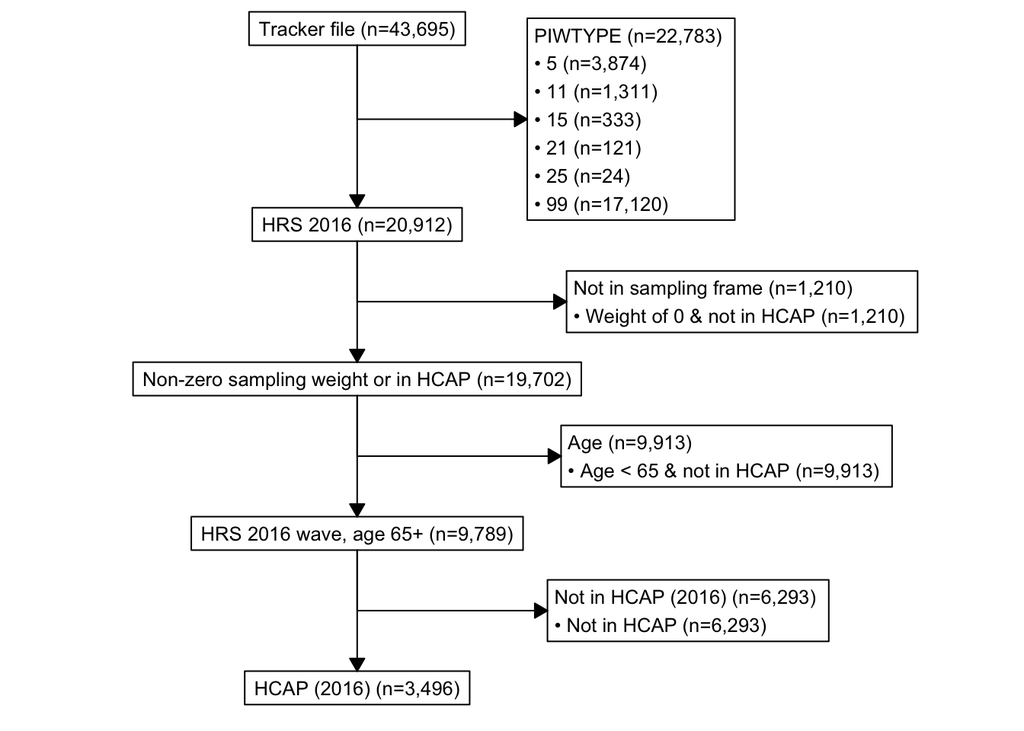

Consort diagram for HRS/HCAP 2016

n=2993 is the nonimputed data

## 4. Analytic Sample Objects

Four analytic datasets are derived from the merged file:

| Object | Filters Applied | Description |
| --- | --- | --- |
| `tracker_merged` | None | Full merged file, all respondents in tracker |
| `hrs16_merged` | Excludes `not_in_hrs16`, `not_in_sampling_frame`, `age_young_or_not_in_hcap` | HRS 2016 analytic sample: core interview, age 65+, non-zero weight or in HCAP |
| `hcap16_merged` | All above + excludes `not_in_hcap` | HCAP 2016 subsample only |
| `hrs16_22_merged` | `inHRS_16 == 1` OR `inHRS_18 == 1` OR `inHRS_20 == 1` OR `inHRS_22 == 1` | Any respondent with at least one core HRS interview across 2016–2022 |

Exclusion flag columns (`not_in_hrs16`, `a`, `not_in_sampling_frame`, `age_young_or_not_in_hcap`, `not_in_hcap`) are dropped from both `hrs16_merged` and `hcap16_merged` after filtering.

## Output Data

| Object | Output File | Description |
| --- | --- | --- |
| `tracker_merged` | `A0_030_tracker_merged.rds` | Full integrated dataset, all respondents |
| `hrs16_merged` | `A0_030_hrs16_merged.rds` | HRS 2016 analytic sample (age 65+, core interview, non-zero weight or in HCAP) |
| `hcap16_merged` | `A0_030_hcap16_merged.rds` | HCAP 2016 subsample |
| `hrs16_consort` | `A0_030_hrs16_consort.rds` | CONSORT flow diagram object |
| `hrs16_22_merged` | `A0_030_hrs16_22_merged.rds` | Multi-wave analytic sample: respondents in any of 2016–2022 |